Ageing Research Reviews 67 (2021) 101302

Available online 17 February 2021

1568-1637/© 2021 The Author(s). Published by Elsevier B.V. This is an open access article under the CC BY license (http://creativecommons.org/licenses/by/4.0/).

Review

Targeting impaired nutrient sensing with repurposed therapeutics to

prevent or treat age-related cognitive decline and dementia: A

systematic review

Benjamin Kioussis <sup>a</sup><sup>,</sup><sup>b</sup><sup>,</sup><sup>1</sup>, Camilla S.L. Tuttle <sup>a</sup><sup>,</sup><sup>c</sup><sup>,</sup><sup>1</sup>, Daniel S. Heard <sup>a</sup><sup>,</sup><sup>d</sup><sup>,</sup><sup>e</sup>, Brian K. Kennedy <sup>f</sup><sup>,</sup><sup>g</sup><sup>,</sup><sup>h</sup>,

Nicola T. Lautenschlager <sup>d</sup><sup>,</sup><sup>i</sup>, Andrea B. Maier <sup>a</sup><sup>,</sup><sup>f</sup><sup>,</sup><sup>g</sup><sup>,</sup><sup>j</sup><sup>,</sup>*

a *Department of Medicine and Aged Care, @AgeMelbourne, Royal Melbourne Hospital, University of Melbourne, Victoria, Australia*

b *University Hospital Geelong, Barwon Health, Melbourne, Victoria, Australia*

c *Centre for Quantitative Neuroimaging, Department of Radiology, Royal Melbourne Hospital, University of Melbourne, Victoria, Australia*

d *North West Mental Health, Melbourne Health, Melbourne, Victoria, Australia*

e *Older Persons Mental Health Service, Canberra Health Services, Canberra, ACT, Australia*

f *Healthy Longevity Program, Yong Loo Lin School of Medicine, National University of Singapore, Singapore*

g *Centre for Healthy Longevity, National University Health System, Singapore*

h *Singapore Institute of Clinical Sciences, A*STAR, Singapore*

i *Academic Unit for Psychiatry of Old Age, Department of Psychiatry, University of Melbourne, Melbourne, Victoria, Australia*

j *Department of Human Movement Sciences, @AgeAmsterdam, Amsterdam Movement Sciences, Vrije Universiteit, Amsterdam, The Netherlands*

A R T I C L E I N F O

*Keywords:*

Aging

Dementia

Cognition

Therapeutics

Organic chemicals

Clinical trial

A B S T R A C T

*Background:* Dementia is a debilitating syndrome that significantly impacts individuals over the age of 65 years.

There are currently no disease-modifying treatments for dementia. Impairment of nutrient sensing pathways has

been implicated in the pathogenesis of dementia, and may offer a novel treatment approach for dementia.

*Aims:* This systematic review collates all available evidence for Food and Drug Administration (FDA)-approved

therapeutics that modify nutrient sensing in the context of preventing cognitive decline or improving cognition in

ageing, mild cognitive impairment (MCI), and dementia populations.

*Methods:* PubMed, Embase and Web of Science databases were searched using key search terms focusing on

available therapeutics such as ‘metformin’, ‘GLP1’, ‘insulin’ and the dementias including ‘Alzheimer’s disease’

and ‘Parkinson’s disease’. Articles were screened using Covidence systematic review software (Veritas Health

Innovation, Melbourne, Australia). The risk of bias was assessed using the Cochrane Risk of Bias tool v 2.0 for

human studies and SYRCLE’s risk of bias tool for animal studies.

*Results:* Out of 2619 articles, 114 were included describing 31 different ‘modulation of nutrient sensing pathway’

therapeutics, 13 of which specifically were utilized in human interventional trials for normal ageing or dementia.

Growth hormone secretagogues improved cognitive outcomes in human mild cognitive impairment, and

potentially normal ageing populations. In animals, all investigated therapeutic classes exhibited some cognitive

benefits in dementia models. While the risk of bias was relatively low in human studies, this risk in animal studies

was largely unclear.

*Conclusions:* Modulation of nutrient sensing pathway therapeutics, particularly growth hormone secretagogues,

have the potential to improve cognitive outcomes. Overall, there is a clear lack of translation from animal models

to human populations.

* Corresponding author at: @Age, Department of Human Movement Sciences, Faculty of Behavioural and Movement Sciences, Vrije Universiteit Amsterdam,

Amsterdam Movement Sciences, Van der Boechorststraat 7, 1081 BT Amsterdam, The Netherlands.

*E-mail address:* a.b.maier@vu.nl (A.B. Maier).

1 Both authors contributed equally.

Contents lists available at ScienceDirect

Ageing Research Reviews

journal homepage: www.elsevier.com/locate/arr

[figure not shown]

https://doi.org/10.1016/j.arr.2021.101302

Received 24 September 2020; Received in revised form 13 February 2021; Accepted 15 February 2021

*Ageing Research Reviews 67 (2021) 101302*

2

**1. Introduction**

Dementia is a syndrome affecting more than 5% of the world’s

population over 60 years of age (Organisation, 2017). Although Alz-

heimer’s disease (AD) is the most common subtype of dementia, many

other subtypes exist including; Vascular Dementia (VD), dementia with

Lewy Bodies (LBD), Parkinson’s dementia (PD) and Frontotemporal

Dementia (FTD) (Organisation, 2017). Ageing is the major risk factor for

the development of all dementia subtypes (Society, 2016). Mechanisti-

cally, ageing is defined as an accumulation of molecular and cellular

damage leading to a gradual decrease in physiological reserves (Orga-

nization, 2017). As such it has been hypothesized that targeting ageing

pathways may be a viable therapeutic option for treating dementia. One

such pathway is the nutrient sensing pathway (Lopez-Otin et al., 2013),

which relates to the detection of extracellular nutrients, for instance

glucose-sensing via the highly evolutionarily-conserved insulin and

IGF-1 signaling (IIS) pathway (Lopez-Otin et al., 2013). Other key

inter-related effectors of the nutrient sensing pathway include the

Mammalian Target of Rapamycin (mTOR), which detects high amino

acid concentrations, AMPK and sirtuins, which detect low energy states,

and transcription factors known as Forkhead box O proteins (FOXO)

(Lopez-Otin et al., 2013; Mc Auley et al., 2017).

Deregulated nutrient sensing is increasingly thought to play a role in

the pathophysiology of neurodegenerative diseases such as AD (Fluegge,

2019; Liu and Sabatini, 2020; Shafei et al., 2017). One of the most

fundamental pathological mechanisms shared by subtypes of dementia

is neurodegeneration (Moya-Alvarado et al., 2016). This process is often

accompanied by impaired neurogenesis (Gao et al., 2017), and

abnormal protein aggregations (Dugger and Dickson, 2017), which

might be driven by dysfunctional autophagy (Wong and Cuervo, 2010).

Nutrient sensing is increasingly emerging both as a key modulator of the

neurogenesis process (Fidaleo et al., 2017), and, via mTOR, of the

autophagic process (Jahrling and Laberge, 2015). In mice, higher mTOR

signaling has been associated with Aβ accumulation, whilst decreasing

mTOR signaling has been shown to reduce Aβ levels (Caccamo et al.,

2010). Human post-mortem studies have found higher levels of acti-

vated mTOR (Griffin et al., 2005; Li et al., 2005) and its downstream

effectors (Tramutola et al., 2015) in affected brain regions of AD and

MCI patients compared to controls. The broad role that deregulated

nutrient sensing may play in dementia offers a possible therapeutic

pathway, as many nutrient sensing-modulating therapeutics, such as

metformin, already exist (Rena et al., 2017). To date, however, the

therapeutic indications of these medications do not include neurode-

generative diseases (Australian Medicines Handbook Pty Ltd., 2021).

The aim of this systematic review is to summarize the evidence in

human and animal populations for the use of Food and Drug Adminis-

tration (FDA) approved nutrient sensing-modifying therapeutics to

prevent age-related cognitive decline or improve cognition in ageing,

mild cognitive impairment (MCI), and dementia populations.

**2. Methods**

*2.1. Selection of articles*

The protocol of this systematic review was registered at PROSPERO

International prospective register of systematic reviews (Reg #:

CRD42018091645). PubMed, Web of Science and Embase databases

were searched until the 29th March 2019. The search strategy (Heard

et al., 2018) focused on key search terms for the dementias, such as; AD,

VD, PD, LBD, and ageing. The strategy also included key terms for

nutrient modulating proteins and therapeutics, such as; insulin, mTOR,

glycogen synthase kinase-3 (GSK-3), metformin, dipeptidyl peptidase-4

(DPP-4) and glucagon-like peptide-1 (GLP-1). The complete search

strategy has been previously published (Heard et al., 2018). In addition

snowballing was used to search references within included articles.

*2.2. Eligibility criteria*

Articles included in this review met the following inclusion criteria:

1) Population – animals or humans; normal ageing or neurodegenerative

disease, such as dementia (AD, VD, PD, or LBD). Populations likely to

have a higher pace of ageing such as Type 2 Diabetes Mellitus (T2DM),

insulin-resistant, or obesity, were also included. In animals, normal

ageing was defined as a strain not at a greater propensity to develop

dementia and not manipulated to mimic dementia. Dementia models

were defined as strains at a greater propensity to develop dementia

compared to normal ageing strains or being modified to become more

likely to develop dementia. In humans, normal ageing was defined as a

population not suffering from dementia or mild-cognitive impairment.

2) Study design – interventional studies with comparators; including

randomized or quasi-randomised controlled trials, cohort studies, and

pre/post studies. 3) Intervention – FDA approved therapeutics known to

influence the nutrient sensing pathway. 4) Outcome – cognitive function

measured using neuropsychological tests. In animals, using mice as an

example, neuropsychological tests may include spatial memory tests

(Morris water maze [MWM], radial arm water maze [RAWM]), asso-

ciative learning tasks (passive avoidance), recognition memory tasks,

and others (Rodriguiz and Wetsel, 2006). In humans, examples of neu-

ropsychological measures include Mini-Mental State Examination

(MMSE), Rowland Universal Dementia Assessment Scale (RUDAS),

Neuropsychiatry Unit Cognitive Assessment Tool (NUCOG), Montreal

Cognitive Assessment (MOCA), Clinical Dementia Rating Scale Sum of

Boxes (CDR-SoB), Addenbrooke’s Cognitive Examination (ACE) or AD

Assessment Scale-cognitive subscale (ADAS-Cog) (Lin et al., 2013).

Articles were excluded if they met one of the following exclusion

criteria: 1) exercise as the sole intervention, 2) *in vitro* data only, 3)

conference abstract, review, editorial, or letter to the editor, 4) ≤5

population size for human studies, 5) intraperitoneal/intravenous

streptozotocin-induced diabetes models unless specifically stated as

recapitulating a T2DM phenotype, due to its otherwise inappropriate-

ness in mimicking the pathogenesis of age-related dementia following

the onset of T2DM diabetes, 6) intracerebroventricular streptozotocin-

induced models without reporting a desired cognitive endpoint of

either cognitive decline or dementia, due to their inappropriateness in

mimicking the pathogenesis of human AD (Grieb, 2016), and 7) pub-

lished in a language other than English.

*2.3. Article selection and data extraction*

Three reviewers (DH, CT and TR) independently screened the titles

and abstracts for inclusion. Full text articles were then screened by two

independent reviewers (DH and TR) to isolate articles of interest. A

fourth reviewer (ABM) resolved any disagreements between the re-

viewers. Articles were screened using Covidence systematic review

software (Veritas Health Innovation, Melbourne, Australia). Included

studies were separated into the following four groups for data extrac-

tion: 1) proteostasis - repurposed therapeutic (please refer to (Heard

et al., 2018)), 2) proteostasis - novel intervention (defined as a novel

molecule, botanical extract, or dietary manipulation), 3) deregulated

nutrient sensing - repurposed therapeutic (reported here) and 4)

deregulated nutrient sensing – novel intervention. Where an interven-

tion is thought to modify both pathways (for example the mTOR in-

hibitor, rapamycin) it was included in the loss of proteostasis group.

Therapeutics that were investigated in articles that passed this selection

process were then screened using the FDA website to ensure that they

met with FDA approval. This systematic review followed the PRISMA

guidelines (Supplementary Table F) and focuses on deregulated nutrient

sensing and repurposed therapeutics.

The following variables were independently extracted for all articles

by two reviewers (BK and DH): author, year of publication, study design,

animal model/population (dementia subtype or normal ageing), meta-

bolic status (T2DM, insulin-resistance or normal), sample size, age, sex,

*B. Kioussis et al.*

*Ageing Research Reviews 67 (2021) 101302*

3

baseline cognition/stage of disease, duration of intervention, cognitive

outcome, therapeutic, comparator group, and hallmark(s) of ageing

targeted by the intervention. For articles using animal models, the

following additional variables were extracted: species, method of de-

mentia induction, and method of metabolic disease induction.

For binary outcomes the number of events and total number in

groups, percentage of events or ratios with confidence intervals, were

extracted; for continuous outcomes, mean or median, with standard

deviation, standard error, confidence intervals or interquartile range,

and number of participants, were extracted, along with other reported

results such as mean difference, *p*-values, or F-statistic for overall mea-

sures of cognitive function.

*2.4. Data analysis*

A semi-quantitative data analysis was performed on extracted

outcome data. Dementia models were considered preventative if the

intervention was administered prior to the onset of dementia, and were

considered to be therapeutic if the intervention was administered after

dementia onset. For animal and human studies, an overall positive effect

of the administered therapeutic on cognitive performance was defined

where a positive primary cognitive outcome was reported, or *>*50% of

the cognitive tests demonstrated a statistically significant improvement

in the treatment group compared to the comparator group. A

moderately-positive result was defined where ≥ 20% of positive

cognitive outcomes were observed, or a single cognitive composite test

(e.g. MMSE), demonstrated a statistically significant improvement in the

treatment group compared to the comparator group. A finding was

considered negative where *<* 20% of the cognitive outcomes were

positive in the treatment group compared to the comparator group.

Finally, a detrimental treatment outcome was defined as a statistically

significant decrease in cognitive performance for the treatment group

compared to the comparator group.

Extracted outcome data for each reported population in all thera-

peutic classes was then stratified according to cohort (normal ageing or

MCI/dementia). In both animals and human studies, a therapeutic class

was considered overall to have a beneficial effect on cognition if ≥50%

of all reported populations (of species) within a given cohort reported an

overall positive effect of the administered therapeutic on cognitive

performance. The size of each population was also taken into account,

whereby a study with larger populations showing no effect of an

administered therapeutic on cognition may warrant reconsideration of a

therapeutic class’ overall efficacy if studies with smaller populations

reported a beneficial cognitive effect.

To investigate for the presence of any correlates that may be found

within therapeutic classes (including T2DM status, sample size, popu-

lation age etc.), populations were ranked in order of: effect of admin-

istered therapeutic on cognition (positive, moderately-positive,

negative, detrimental effect), followed by population cohort (AD, PD,

VD, MCI, dementia, normal ageing), method of induction of dementia/

metabolic disease (for animals), duration of administered therapeutic,

dose of administered therapeutic, and were visually examined for any

indications of bias.

Articles within therapeutic classes were compared for their amena-

bility to meta-analysis, including aspects such as: cohort, cognitive

outcome measure, test condition, unit of test, and reported comparative

method by which measures of significance were made within the article

(Stone and Rosopa, 2017).

*2.5. Registered human trials*

To provide an overview of the progress in the field of repurposing

therapeutics in humans to prevent the onset of age-related cognitive

decline or treat mild cognitive impairment (MCI) and dementia, clinical

trials registered before 4th of July 2020 that have not yet provided re-

sults, were summarized by searching clinicaltrials.gov. The conditions:

aging; mild cognitive impairment; Alzheimer disease; vascular demen-

tia; Parkinson disease; Lewy Body disease were key words that were

searched for each of the therapeutic classes, for studies of all phases

utilizing adult participants.

*2.6. Risk of bias*

The risk of bias was assessed by two reviewers (BK, DH) using the

Cochrane Risk of Bias tool v 2.0 for human studies (Higgins et al., 2011)

and SYRCLE’s risk of bias tool for animal studies (Hooijmans et al.,

2014). The Cochrane Risk of Bias tool v 2.0 analyses bias using six key

sources of bias, specifically; sequence generation, allocation conceal-

ment, blinding of participants and personnel, random outcome assess-

ment, incomplete outcome data, and selective outcome reporting. Each

of these was denoted ‘green’ for ‘low risk’ if this aspect was reported and

deemed to mitigate bias, ‘orange’ for ‘some concerns’ if anything less

than an absolute mitigation of bias was reported, and ‘red’ for ‘high risk’

if this aspect was reported and deemed to encourage bias. SYRCLE’s risk

of bias tool for animal studies analyses bias using the above categories

but also includes baseline characteristics, and random housing. Each of

these categories was denoted ‘green’ for ‘low risk’ if this aspect was

reported and deemed to mitigate bias, ‘blue’ for ‘unclear’ if this aspect

was not reported, and ‘red’ for ‘high risk’ if this aspect was reported and

deemed to encourage bias. Overall, a given human or animal study was

classified as low risk of bias if *<*2 sources of bias was deemed to have

‘some concerns’, and no source of bias was deemed to have high risk of

bias. Possible financial conflict of interest was assessed by evaluating

disclosed affiliations to a known pharmaceutical company.

**3. Results**

*3.1. Study selection and characteristics*

Overall, 114 articles were analyzed (animals n = 91 articles and

human n = 23 articles), of which 81/91 articles focused on a dementia

model in animals (58/91 mice as the experimental model), while 17/23

articles focused on MCI/dementia pathology in humans (Fig. 1). Table 1

provides an overview of the population demographics for all articles,

and the domains of cognition tested. For a detailed description of all

been tested for their effect on cognitive outcomes in either animal or

human subjects. Of these, in animal models, GLP-1 agonists were the

most tested therapeutic (13/91), followed by glitazones (10/91). In

human studies, intranasal insulin was the most tested therapeutic (7/

23), followed by glitazones (5/23). Glitazones, GLP-1 agonists, growth

hormone, growth hormone secretagogues, metformin, and intranasal

insulin, have been assessed in both animal and human subjects. For a

detailed description of all reported cognitive outcomes please refer to

*Supplementary Tables B.1* and *B.2*. Fig. 2 provides a summary of the re-

sults of all interventions tested. Fig. 3 shows the status of interventional

trials registered by 4th July 2020 on clinicaltrials.gov that have not yet

released their results, investigating the influence of nutrient sensing-

modifying therapeutics on cognitive outcomes in human populations.

For a detailed description of the status of these registered interventional

trials please refer to *Supplementary Table C*.

*3.2. Glitazones*

Glitazones regulate gene expression by binding to the nuclear tran-

scription regulator peroxisome proliferator-activated receptor-gamma,

to enhance insulin sensitivity and action. They are currently approved

by the FDA for use as monotherapy or in combination with sulfonylureas

or metformin for the management of T2DM (Eggleton and Jialal, 2019).

Overall, 15/114 studies (10 animal, 5 human) investigated the effect of

glitazones on cognition in normal ageing (6/15 studies) or dementia

*B. Kioussis et al.*

*Ageing Research Reviews 67 (2021) 101302*

4

(15/15 studies) populations. These studies sometimes investigated more

than one disease population. In animals, across these 10 studies, 10

normal ageing populations (Baraka and ElGhotny, 2010; Denner et al.,

2012; Jiang et al., 2012; Liu et al., 2010; Masciopinto et al., 2012;

Rodriguez-Rivera et al., 2011) and 18 dementia populations (Baraka and

ElGhotny, 2010; Denner et al., 2012; Gad et al., 2016; Jiang et al., 2012;

Kummer et al., 2015; Li et al., 2018; Liu et al., 2010; Masciopinto et al.,

2012; Rodriguez-Rivera et al., 2011; Toledo and Inestrosa, 2010) have

been assessed, including two studies with preventative models (Mas-

ciopinto et al., 2012; Rodriguez-Rivera et al., 2011). Glitazones likely

have an overall significant beneficial effect on cognition in animal

therapeutic dementia models, but not in preventative dementia models

or normal animal ageing models (Fig. 2). This effect was not related to

the method of disease induction (T2DM or otherwise), administered

therapeutic, dose, duration, sample size, cognitive domain assessed or

quality of the article (Fig. 4**a** and *Supplementary Table B.1*). In humans,

across these five studies, glitazones overall did not positively affect

cognitive outcomes in 27 MCI/dementia populations (Gold et al., 2010;

Harrington et al., 2011; Sato et al., 2011; Tzimopoulou et al., 2010;

Watson et al., 2005) (Fig. 2).

*3.3. GLP-1 agonists*

GLP-1 agonists function by stimulating insulin secretion via the

incretin response, and are approved for use in T2DM (Collins and

Costello, 2019). Overall, 15/114 studies (13 animal, 2 human) investi-

gated the effect of GLP-1 agonists on cognition in normal ageing (6/15

studies) or dementia (13/15 studies) populations. These studies some-

times investigated more than one disease population. In animals, across

these 13 studies, 8 normal ageing populations (Huang et al., 2012;

Isacson et al., 2011; McClean and Holscher, 2014a, b; Wang et al., 2016)

and 20 dementia populations (Bomba et al., 2013; Bomfim et al., 2012;

Gad et al., 2016; Gumuslu et al., 2016; Kamble et al., 2016; Lennox et al.,

2014; Li et al., 2016; McClean and Holscher, 2014a, b; Solmaz et al.,

2015; Wang et al., 2016) have been assessed, including one study with a

preventative model (Wang et al., 2016). GLP-1 agonists likely have an

overall significant beneficial effect on cognition in animal therapeutic

dementia populations (including a therapeutic VD model (Li et al.,

2016)), but not in normal ageing populations (Fig. 2). Additionally, a

single rat preventative model showed a beneficial effect on cognitive

outcomes (Fig. 2). This effect was independent of the method of disease

induction (T2DM or otherwise), administered therapeutic, dose, dura-

tion, sample size, cognitive domain assessed or quality of the article

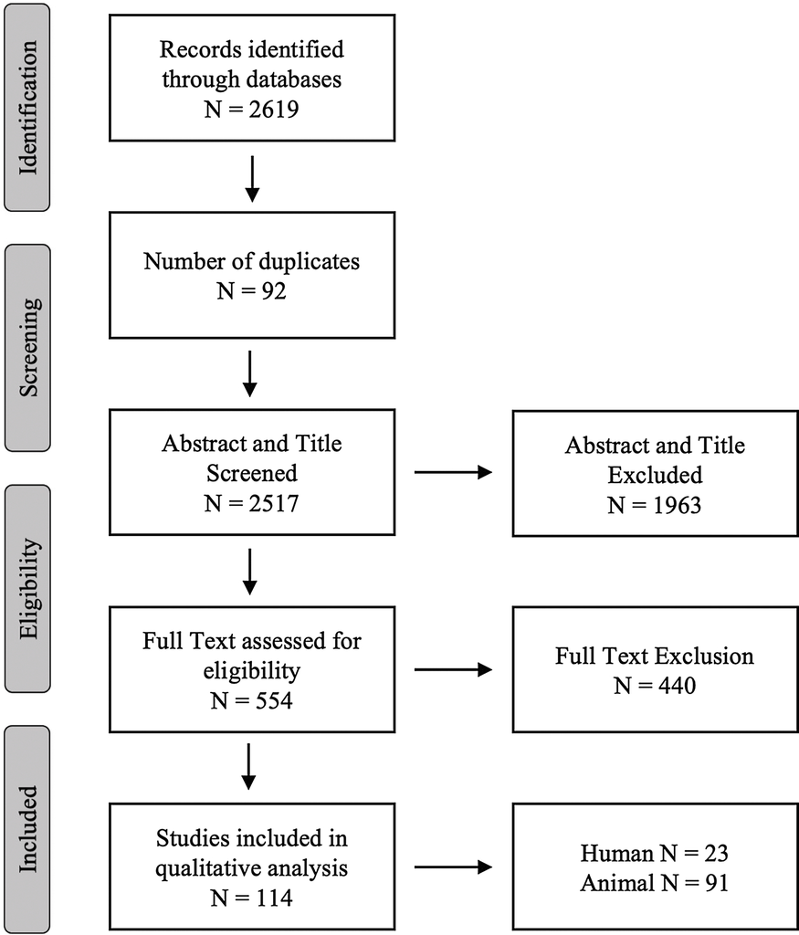

**Fig. 1.** Schematic overview of the search.

*B. Kioussis et al.*

*Ageing Research Reviews 67 (2021) 101302*

5

**Table 1**

Study designs of nutrient sensing-modifying therapeutics and cognitive tests in animal and human subjects, stratified by species.

Species

Experimental model

A,

n

G,

n

Rx, n

Ctrl, n

Cognitive tests

Domains of cognition

**Glitazones**

Mouse

AD (TG), AD + T2DM (TG +

Streptozotocin IV)

5

12

145

124

FCT, MWM, NOR

Contextual memory, hippocampal memory

formation, cognitive function, short and long-term

spatial memory, ability to build spatial

relationships, fear-conditioned learning

AD (TG)

1

1

NR

NR

MWM, MFT

Spatial memory, memory flexibility

D + T2DM (Streptozotocin IV +

HFD)

1

2

20

10

MWM, YM

Learning and memory behaviour

Normal ageing

4

8

99

85

FCT, STT, YM, MWM, NOR

Contextual memory, learning and memory

behaviour, short and long-term spatial memory,

ability to build spatial relationships, fear-

conditioned learning

Rat

AD (AB ICV)

1

1

9

8

MWM, PAT

Spatial memory, learning and memory performance

D + IR (HFD)

2

2

20

20

ERAM, MWM

Learning and memory, change of learning and

memory abilities

Normal ageing

2

2

20

20

MWM, PAT

Spatial memory, learning and memory performance,

change of learning and memory abilities

Human

AD/MCI

5

27

3524

917

ADAS-Cog, CIBIC+, NPI, DAD, MMSE,

Q1&7 from ADAS-Cog, CDR-SB,

ADAS-Jcog, WMS-R logical memory I,

FAB, CF, BSRT, SR, SSA

Cognition, global function, behavioural and

psychological symptoms of dementia, ability to

perform activities of daily living, cognitive status,

short-term memory, changes in cognition and global

function, verbal memory, selective attention,

category fluency

**GLP-1 agonists**

Mouse

AD (TG)

4

10

95

59

MWM, NOR, RMWM, OFT

Spatial memory, object recognition memory, spatial

learning, motor activity, speed, anxiety and

exploratory behaviour, recognition memory

D + T2DM (Streptozotocin IV), D

(Pentylenetetrazole IP), D + IR

(HFD)

3

4

36

30

EPM, PAT, OFT, MWM, NOR

Spatial memory function, emotional memory

function, locomotor activity, anxiety-behaviour,

motor activity, speed, anxiety and exploratory

behaviour, recognition memory

VD + T2DM (MCAO + db/db mice)

1

1

6

6

NSB

Motor and cognitive function

Normal ageing

3

6

85

49

MWM, NOR, RMWM, OFT

Spatial reference learning and memory, object

recognition memory, motor activity, speed, anxiety

and exploratory behaviour, recognition memory

Rat

AD (Streptozotocin ICV), AD (AB

ICV)

2

2

17

17

PAT, MWM

Cognitive performance, spatial learning and

memory ability

D + IR (HFD), D (Scopolamine IP)

2

3

26

16

ERAM, MWM

Learning and memory, cognitive behaviour

Normal ageing

2

2

21

23

ERAM

Hippocampus-based cognitive performance

Human

AD

1

1

15

11

BVRT, CVLT-II, D-KEFS, RCFT, PP,

WAIS-III, WASI: Vocabulary and

Matrix Reasoning

Working memory, processing speed, visuospatial

and constructional abilities, verbal and visual

memory, verbal fluency, executive functioning, and

fine motor abilities

Normal ageing

1

1

18

20

WMS-IV

Spatial orientation, time estimation, mental control,

clock drawing, incidental recall, inhibition, verbal

reproduction

**Growth hormone**

Rat

Normal ageing

1

1

12

12

MWM

Spatial learning

Human

Normal ageing

1

1

26

26

TB, MMSE, DSST

Visual and motor tracking and attention,

orientation, attention, calculation, language,

memory, cognitive impairment

**Growth hormone secretagogues**

Mouse

AD + T2DM (TG + HFD)

1

1

9

10

MWM

Spatial learning

Rat

AD (Monosodium L-glutamate IP)

1

1

6

6

BMT

Spatial learning and memory

Human

MCI

2

3

39

39

EF, VM, VisM

Memory, executive function, word fluency, episodic

memory

Normal ageing

3

4

86

92

EF, VM, VisM, WAIS-R, SDT, FINDA,

LETSET, CATFLU, FAS

Memory, executive function, word fluency, episodic

memory, problem solving and psychomotor

processing speed, working memory, reaction time,

cognitive processing speed, highly over-learned

verbal knowledge/crystallised intelligence

**Metformin**

Mouse

AD (AlCl3), AD (TG)

2

2

16

16

MWM

Spatial learning, short-term memory, spatial

learning and memory

D + T2DM (db/db mice), AD + IR

(HFD)

3

3

38

38

MWM

Spatial learning, short-term memory, cognitive

performance, spatial learning and memory

Normal ageing

2

4

58

58

MWM, DAT

Spatial learning, short-term memory, spatial

memory

Rat

D + IR (HFD), D + T2DM

(Scopolamine IP)

2

3

44

32

MTP

Cognitive performance

Normal ageing

1

1

16

16

MTP

Cognitive performance

Human

Normal ageing + IR

1

1

776

755

SEVLT, DSST, AF, LF, CCM

Memory, frontal-executive abilities

**Intranasal insulin**

(*continued on next page*)

*B. Kioussis et al.*

*Ageing Research Reviews 67 (2021) 101302*

6

**Table 1** (*continued*)

Species

Experimental model

A,

n

G,

n

Rx, n

Ctrl, n

Cognitive tests

Domains of cognition

Mouse

AD (TG), AD (SAMP8 mice)

2

10

103

54

OFT, MWM, RMWM, TMT, NOR

Anxiety and exploratory activities, spatial learning

and memory, behavioural plasticity, hippocampal

dependence of memory, declarative memory

Normal ageing

1

1

5

5

TOD, ORL, NOR

Short and long-term object memory recognition,

olfactory discrimination, odour reversal learning

Rat

AD (Streptozotocin ICV)

1

1

15

14

OFT, MWM

Cognitive function

Normal ageing

2

8

80

50

MWM

Spatial learning, short-term memory, spatial

learning and memory

Human

AD/MCI

5

29

228

108

DSR, DSRS, ADAS-Cog, ADCS-ADL,

VM, DNB, BVRT, SCWIT, DVMC,

ADAS-Cog12, WMS-RLM

Cognition, verbal memory, verbal working memory,

visuospatial working memory, executive function,

functional ability, delayed memory, functional

status, memory, praxis, orientation, and language,

ADL’s, delayed verbal memory, memory and

disability

AD/MCI

2

5

35

35,

cross-

over

SR, LR, SOPT, SCWT, VS, RBANS,

WAIS-IV, TM, BNT, SMT

Verbal declarative memory, selective attention,

visual search, learning/memory, language,

attention/executive function, visuospatial function,

olfaction

Normal ageing

1

2

35

35,

cross-

over

SR, LR, SOPT, SCWT, VS

Verbal declarative memory, visual working

memory, selective attention, visual search

**Insulin infusion**

Human

AD/MCI

2

4

30

30,

pre-

post

MR, SCWIT, DLM, SRT, SR, BSRT,

SOPT

Attention and working memory, verbal episodic

memory, logical memory, verbal memory, complex

attention

Normal ageing

1

2

30

0

MR, SCWIT

Attention and working memory

Normal ageing

3

3

72

72,

pre-

post

DLM, SRT, SR, MMSE, SCWIT, BSRT,

SOPT

Verbal episodic memory, logical memory,

declarative memory, general orientation and

cognitive ability, selective attention, verbal

memory, complex attention

**Octreotide**

Human

AD/MCI

1

3

16

16,

pre-

post

SR, BSRT, SCWIT, SOPT

Verbal memory, complex attention

Normal ageing

1

1

19

19,

pre-

post

SR, BSRT, SCWIT, SOPT

Verbal memory, complex attention

**Octreotide** **þ** **insulin infusion**

Human

AD/MCI

1

3

16

16,

pre-

post

SR, BSRT, SCWIT, SOPT

Verbal memory, complex attention

Normal ageing

1

1

19

19,

pre-

post

SR, BSRT, SCWIT, SOPT

Verbal memory, complex attention

**Beta blockers**

Mouse

AD (TG), AD (SAMP8 mice)

2

3

24

24

NOR, FCT

Spatial working memory, recognition memory,

cognitive memory

D + IR (corticosterone)

1

1

8

8

NOR

Recognition memory

Normal ageing

3

4

32

32

NOR, FCT

Spatial working memory, recognition memory

cognitive memory

**DPP-4 inhibitors**

Mouse

AD (TG)

2

5

34

13

MWM, YM, OFT

Reference and working memory, spatial learning

function, spontaneous exploratory activity and

anxiety-like behaviour

D (Pentylenetetrazole IP), D (Klotho

-/- mice)

2

3

21

21

EPM, PAT

Anxiety-behaviour, cognitive impairment

Rat

AD (Streptozotocin ICV), AD +

T2DM (AB ICV + Streptozotocin

IP), AD (AB ICV)

3

6

65

35

RAM, HBT, PAT, MWM

Reference and working memory, learning deficits in

a food-motivated complex HB apparatus, measure of

cognitive decline, spatial learning and memory

D (Scopolamine IP), D + IR (HFD)

3

4

38

28

MWM

Cognitive behaviour, cognitive function

PD (6OHDA)

1

1

8

8

NOR

Object recognition memory

Normal ageing

3

4

40

30

MWM, NOR

Cognitive behaviour, cognitive function, object

recognition memory

**Melatonin**

Mouse

AD (TG)

1

1

11

13

NOR

Learning and memory

D (Scopolamine IP)

1

1

14

14

MWM, YM

Spatial working memory

Normal ageing

1

1

12

16

NOR

Learning and memory

Rat

AD (OXYS rats)

1

1

25

25

EPM, OFT, ERAM

Anxiety-behaviour, locomotor and exploratory

activity, learning and memory

Normal ageing

1

1

25

25

EPM, OFT, ERAM

Anxiety-behaviour, locomotor and exploratory

activity, learning and memory

**N-methyl**-D-**aspartate receptor antagonist**

Mouse

AD (TG), AD + IR (TG + HFD)

1

2

20

20

MWM, NOR

Spatial memory and learning, hippocampal-

dependent recognition memory

Rat

3

4

35

33

MWM, PAT

(*continued on next page*)

*B. Kioussis et al.*

*Ageing Research Reviews 67 (2021) 101302*

7

**Table 1** (*continued*)

Species

Experimental model

A,

n

G,

n

Rx, n

Ctrl, n

Cognitive tests

Domains of cognition

AD (Streptozotocin ICV), AD +

T2DM (AB ICV + Streptozotocin

IP), AD (Poly-APS/Tau ICV)

Learning and memory capacity, measure of

cognitive decline, spatial reference memory

**PDE-inhibitors**

Monkey

Normal ageing

1

6

14

14,

pre-

post

OR

Prefrontal executive function

Mouse

AD (TG)

2

2

21

20

MWM, FCT

Spatial memory, contextual memory, spatial

learning and cognitive performance

AD (AB ICV)

1

4

NR

NR

MWM

Spatial learning and memory

D (SAMP8 mice), D (Scopolamine

SC)

2

5

45

45

MWM, YM

Spatial memory, immediate spatial working

memory

Normal ageing

5

15

158

167

MWM, FCT, FTC, NOR

Spatial memory, contextual memory, hippocampal-

dependent context conditioning, long-term memory

formation, hippocampal-dependent long-term

spatial memory, memory

Normal ageing

1

2

NR

NR

OFT, VPWM

Hippocampus-independent memory

Rat

VD (4VO), VD (MMI)

2

3

31

20

OFT, MWM, NOR, OT

Locomotor activity levels and anxiety, memory and

learning capacity, short-term memory, spatial

learning and memory, long-term learning and

memory

Normal ageing

1

1

5

10

NOR, OT, MWM

Short-term memory, spatial learning and memory,

long-term learning and memory

**Selective serotonin reuptake inhibitors**

Mouse

AD (TG)

1

1

20

20

MWM

Spatial learning ability

Rat

D (Forskolin ICV)

1

1

12

12

MWM

Spatial learning and memory

Normal ageing stress resistant,

Normal ageing stress susceptible

1

2

16

16

MWM

Spatial learning and referential memory

**Statins**

Mouse

AD (AB ICV)

2

2

18

18

MWM, YM

Spatial memory, long-term memory, short-term

memory

Normal ageing

2

2

22

22

MWM, YM

Spatial cognitive performance, spatial memory

Rat

Normal ageing

1

2

20

10

MWM, YM

Long-term memory, short-term memory

**Acarbose**

Mouse

D (SAMP8 mice)

1

1

9

8

MWM

Spatial learning and memory

**Adrenoceptor agonist**

Chicken

AD (AB intra-cortical)

1

9

108

48

DAT

Memory retention

**AMPK activator**

Mouse

AD + T2DM (TG + Streptozotocin

ICV)

1

1

10

10

MWM, NOR

Cognitive function

**Amylin** **&** **analogues**

Mouse

AD (TG), AD (SAMP8 mice)

2

3

30

30

YM, MWM, NOR

Short-term memory, long-term spatial memory

Normal ageing

1

1

10

10

YM, MWM

Short-term memory, long-term spatial memory

**Angiotensin receptor blockers**

Mouse

AD (TG)

1

2

14

14

MWM

Learning and memory

Normal ageing

1

2

14

14

MWM

Learning and memory

Rat

AD (Angiotensin II ICV)

1

1

12

12

MWM

Cognitive and behavioural performance

Normal ageing

1

1

12

12

MWM

Cognitive and behavioural performance

**Anti-IL1R antibody**

Mouse

AD (TG)

1

1

8

10

MWM, FCT

Hippocampal-dependent cognition, amygdala and

hippocampal function

**Bioflavanoid**

Mouse

AD (TG)

1

2

24

12

NOR, MWM

Recognition memory, spatial reference learning and

memory

**Caffeine**

Mouse

AD (TG)

1

1

6

7

RAWM, PR

Working memory, identification and recognition

Normal ageing

1

1

8

11

YM, MWM, CP, PR, RAWM

Sensorimotor and cognitive function, spatial

learning and reference memory, identification and

recognition, working memory

Rat

D + IR (HFD)

1

1

8

8

SAT

Measure of working memory

Normal ageing

1

1

8

8

SAT

Measure of working memory

**Dexibuprofen**

Mouse

AD (TG)

1

1

10

10

NOR

Hippocampal-dependent recognition memory

**Gonadotropin releasing hormone agonist**

Mouse

AD + Ovarectomised (TG)

1

1

6

6

MWM

Hippocampal-dependent spatial learning and

memory

**ICV insulin**

Rat

AD (Streptozotocin ICV)

1

1

7

7

MWM

Learning and memory capability

**IGF-1**

Mouse

AD (TG)

1

1

12

12

MWM

Spatial memory

**JNK inhibitor**

Mouse

AD (SAMP8 mice)

1

1

10

10

MWM

Spatial memory

Normal ageing

1

1

10

10

MWM

Spatial memory

**Rho-kinase inhibitor**

Rat

AD (Streptozotocin ICV)

1

1

6

6

MWM, NOR

(*continued on next page*)

*B. Kioussis et al.*

*Ageing Research Reviews 67 (2021) 101302*

8

(Fig. 4**a** and *Supplementary Table B.1*). Across 2 human studies, GLP-1

agonists do not have a significant effect on cognition in the human

normal ageing population (Watson et al., 2019) or dementia population

(Gejl et al., 2016) (Fig. 2).

*3.4. Growth hormone*

Whilst growth hormone (GH) receptors are present in many organs,

the many metabolic and growth-related effects of GH are accomplished

both directly via receptor-signaling, and indirectly via insulin-like

growth factor (IGF) (Brooks and Waters, 2010). GH use is approved by

the FDA for the treatment of GH deficiency, hypopituitarism, AIDS

wasting syndrome, and short bowel syndrome (Sigalos and Pastuszak,

2018). Overall, 2/114 studies (1 animal, 1 human) each investigated the

effect of GH on cognition in one normal ageing population. GH may have

a beneficial effect on cognition in normal ageing animals (Ramsey et al.,

2004), and a possible positive effect in normal ageing humans (Papa-

dakis et al., 1996) (Fig. 2).

*3.5. Growth hormone secretagogues*

Growth hormone secretagogues, which include growth hormone

releasing hormone agonists, and growth hormone secretagogue receptor

agonists (the natural ligand of which is ghrelin), have been evaluated for

use in growth retardation, altered body composition, and gastrointes-

tinal dysfunction, some of which have been approved by the FDA (Ishida

et al., 2020). Overall, 5/114 studies (2 animal, 3 human) investigated

the effect of growth hormone secretagogues on cognition in normal

ageing (3/5 studies) or dementia (4/5 studies) populations. These

studies sometimes investigated more than one disease population. In

animals, across 2 studies, growth hormone secretagogues have a sig-

nificant beneficial effect on cognition in animal therapeutic dementia

populations (Fig. 2) (Kunath et al., 2015; Madhavadas et al., 2014). In

humans, across 3 studies, three normal ageing populations and one

mixed normal ageing/MCI population (Baker et al., 2012; Friedman

et al., 2013; Vitiello et al., 2006), and two MCI populations (Baker et al.,

2012; Friedman et al., 2013) were investigated for changes in cognitive

outcomes. Growth hormone secretagogues likely have a significant

beneficial effect on cognition in human MCI populations, and may have

a beneficial effect on cognition in human normal ageing populations

(Fig. 2). In humans, this effect was independent of administered thera-

peutic, dose, duration, cognitive domain assessed, quality of the article,

or number of participants (Fig. 4**b** and *Supplementary Table B.2*). The

number of participants in each population varied between the two

studies examining MCI/dementia cohorts (eight (Friedman et al., 2013)

to 31 (Baker et al., 2012) participants receiving treatment) and the three

studies examining normal ageing cohorts (six (Friedman et al., 2013) to

67 in the mixed normal ageing/MCI (Baker et al., 2012) receiving

**Table 1** (*continued*)

Species

Experimental model

A,

n

G,

n

Rx, n

Ctrl, n

Cognitive tests

Domains of cognition

Spatial memory, non-spatial recognition and

memory

**Subcutaneous insulin**

Rat

AD (AB ICV)

1

1

8

8

MWM

Place navigation and spatial probing

D + T2DM (Streptozotocin IP)

1

1

10

10

MWM, YM

Long-term memory, short-term memory

**Sulfonylureas**

Rat

AD (AB ICV)

1

1

9

8

MWM, PAT

Spatial memory, learning and memory performance

Normal ageing

1

1

10

10

MWM, PAT

Spatial memory, learning and memory performance

**DPP-4 inhibitor** **þ** **memantine**

Rat

AD + T2DM (AB ICV +

Streptozotocin IP)

1

1

15

15

PAT

Measure of cognitive decline

**Glitazone** **þ** **GLP-1 agonist**

Rat

D + IR (HFD)

1

2

20

10

ERAM

Learning and memory

**ICV insulin** **þ** **memantine**

Rat

AD (Streptozotocin ICV)

1

2

14

7

MWM

Learning and memory capability

**Metformin** **þ** **drug cocktail**

Mouse

AD + T2DM (TG + db/db mice), AD

(TG)

1

2

20

23

MWM, NOR

Spatial cognition, episodic memory

D + T2DM (db/db mice)

1

1

8

10

MWM, NOR

Spatial cognition, episodic memory

**Metformin** **þ** **GLP-1 agonist**

Mouse

D + T2DM (db/db mice)

1

2

20

10

MWM

Spatial learning and memory

4VO: 4 vessel occlusion, A: articles, AB: amyloid beta, ADAS-Cog: Alzheimer’s Disease Assessment Scale-Cognitive Subscale, ADAS-Jcog: Japanese version, ADCS-ADL:

Alzheimer’s Disease Cooperative Study - activities of daily living, AF: Animal fluency, AlCl3: aluminium chloride, AMPK: AMP-activated protein kinase, BMT: Barnes

maze test, BNT: Boston naming test, BSRT: Buschke selective reminding test, BVRT: Benton Visual Retention Test, CATFLU: Category fluency task, CCM: Composite

cognition measure, CDR-SB: Clinical Dementia Rating Scale sub of boxes, CF: Category Fluency, CIBIC+: Clinician’s Interview-Based Impression of Change plus

caregiver input, CP: Circular platform, Ctrl: control, CVLT: California Verbal Learning Test, DAD: Disability Assessment for Dementia, DAT: Discrimination avoidance

task, D-KEFS: Delis-Kaplan Executive Functioning System, DLM: Delayed logical memory, DMTS: Delayed match to sample, DNB: Dot N-Back, DPP-4: dipeptidyl

peptidase-4, DSRS: Dementia Severity Rating Scale, DSST: Digit symbol substitution test, EF: Executive function, EPM: Elevated plus maze, ERAM: Eight radial arm

maze, FAB: Frontal Assessment Battery, FAS: FAS verbal fluency task, FCT: Fear conditioning task, FINDA: Finding A’s task, FTC: Freezing to context, G: populations,

GLP-1: glucagon-like peptide 1, HBT: Hole-board task, HFD: high-fructose diet, ICV: intracerebroventricular, IG: intragastric, IGF: insulin-like growth factor, IL1R:

interleukin-1 receptor, IP: intraperitoneal, IR: insulin-resistant, IV: intravenous, JNK: c-Jun N-terminal kinase, LETSET: Verbal sets task, LF: Letter fluency, LR: List

recall, MCAO: middle cerebral artery occlusion, MFT: Memory flexibility test, MMI: multiple microinfarction, MMSE: Mini-Mental State Examination, MTP: Matching

to position, NMTP: Non-matching to position, NOR: Novel object recognition, NR: not reported, NSB: Novel sniffing behavior, OFT: Open field test, OR: Object

retrieval, ORL: Odor reversal learning, OT: Odor test, PAT: Passive avoidance test, PDE: phosphodiesterase, Population; [AD: Alzheimer’s disease, D: dementia, PD:

Parkinson’s disease, VD: vascular dementia], PP: Purdue Pegboard, PR: Platform recognition, RAWM: Radial arm water maze, RBANS: Repeatable battery for the

assessment of neuropsychological status, RCFT: Rey Complex Figure Test, RMWM: Reverse Morris Water Maze, Rx: treatment, SAT: Spontaneous alternation testing,

SC: subcutaneous, SCWT: Stroop Color-Word Test, SCWIT: Stroop Color-Word Interference Task, SDT: Single-dual task, SEVLT: Spanish English Verbal Learning Test,

SMT: Sniff magnitude test, SOPT: Self-ordered pointing task, SR: Story Recall; immediate (ISR) and delayed (DSR), SRT: Free and Cued Selective Reminding Test, SSA:

Stroop selective attention, STT: Shock threshold test, T2DM: Type 2 Diabetes Mellitus, TB: Trails B, TG: transgenic, TM: Trail making, TMSA: Trail making test selective

attention, TMT: T-maze test, TOD: Two odour discrimination, VisM: Visual memory, VM: Verbal memory, VMC: Verbal memory composite; delayed (DVMC), VPWM:

Visible platform water maze, VS: Visual search, WAIS: Wechsler Adult Intelligence Scale, WAIS-R: Wechsler Adult Intelligence Scale Revised, WASI: Wechsler

Abbreviated Scale of Intelligence, WMS: Weschler Memory Scale, WMS-R: Wechsler Memory Scale Revised, YM: Y-Maze test.

*B. Kioussis et al.*

*Ageing Research Reviews 67 (2021) 101302*

9

treatment).

*3.6. Metformin*

Metformin is a biguanide which lowers blood glucose levels by

decreasing intestinal absorption, decreasing production of hepatic

glucose, and increasing insulin sensitivity, and is the preferred approved

first-line therapeutic for use in T2DM (Collins and Costello, 2019; Cor-

coran and Jacobs, 2018). Overall, 9/114 studies (8 animal, 1 human)

investigated the effect of metformin on cognition in normal ageing (4/9

studies) or dementia (7/9 studies) populations. These studies sometimes

investigated more than one disease population. In animals, across 8

studies, five normal ageing populations (Ahmed et al., 2017; McNeilly

et al., 2012; Thangthaeng et al., 2017) and eight dementia populations

(Ahmed et al., 2017; Allard et al., 2016; Chen et al., 2019a, b; McNeilly

et al., 2012; Mostafa et al., 2016; Ou et al., 2018) have been assessed.

Metformin shows a beneficial effect on cognition in animal therapeutic

dementia populations, but not normal ageing populations (Fig. 2). This

effect was independent of the method of disease induction (T2DM or

otherwise), dose, duration, sample size, cognitive domain assessed or

quality of the article (Fig. 4**a** and *Supplementary Table B.1*). In humans, in

a single study, one normal ageing population with insulin resistance

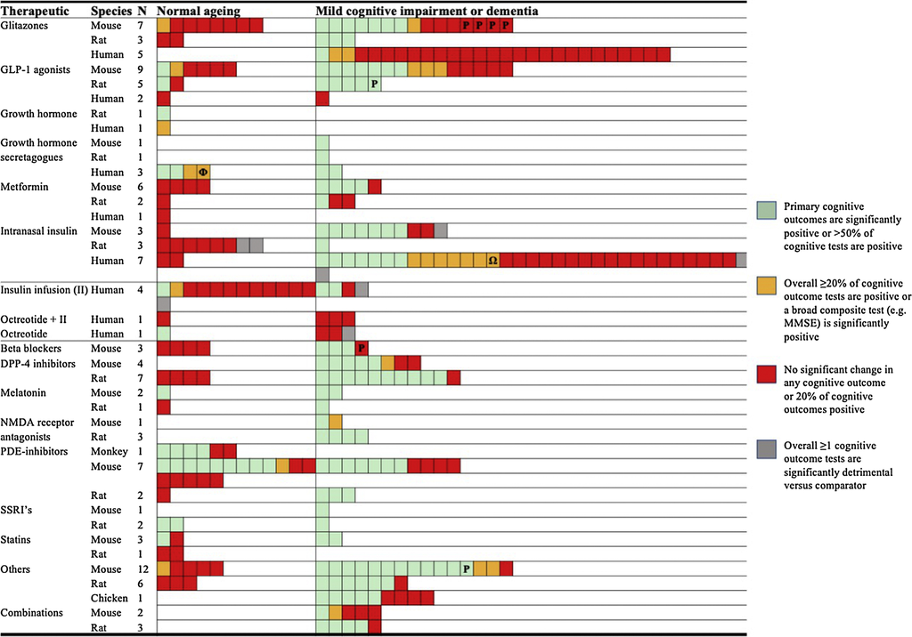

**Fig. 2.** Outcome of trials in animals and humans investigating nutrient sensing-modifying therapeutics on cognitive performance.

A, n = number of articles, DPP-4 = dipeptidyl peptidase-4, GH = growth hormone, GLP-1 = glucagon-like peptide 1, II = insulin infusion, NMDA = N-methyl -D-

aspartate, PDE = phosphodiesterase, RA = receptor antagonist, SSRI = selective serotonin reuptake inhibitor. P = Preventative model, with therapeutic being given

prior to the cognitive onset of dementia.

Ф = These two populations were mixed, with ~55% being Normal Ageing and ~45% being MCI.

Ω = Statistical run-in plots suggested that this ‘improvement’ in ADAS-Cog could have followed a chance worsening and represent regression to the mean.

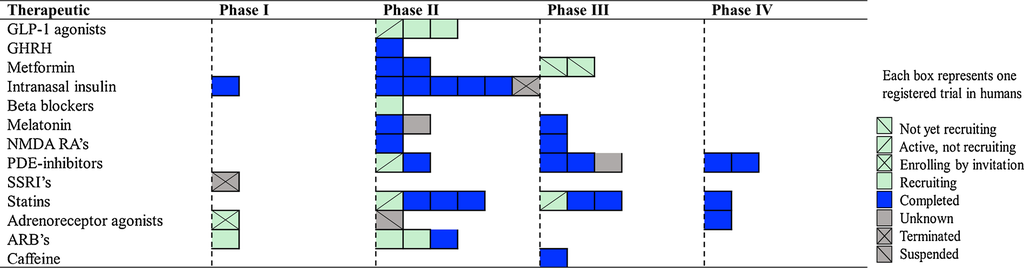

**Fig. 3.** Overview of registered trials in humans investigating nutrient sensing-modifying therapeutics on cognitive performance, that have not yet released results.

ARB = angiotensin receptor blocker, GHRH = growth hormone releasing hormone, GLP-1 = glucagon-like peptide 1, NMDA = N-methyl-D-aspartate, PDE =

phosphodiesterase, RA = receptor antagonist, SSRI = selective serotonin reuptake inhibitor.

*B. Kioussis et al.*

*Ageing Research Reviews 67 (2021) 101302*

10

(Luchsinger et al., 2017) showed a non-significant effect of Metformin

on cognition (Fig. 2).

*3.7. Intranasal insulin*

Insulin receptors are widely distributed throughout the brain, and

intranasal delivery of insulin has been shown to achieve excellent

penetration into the brain – potentially augmenting roles played by

endogenous insulin such as the regulation of neuronal processes of

metabolism, plasticity, growth, cholinergic function, and survival (de la

Monte, 2013). Overall, 13/114 studies (6 animal, 7 human) investigated

the effect of intranasal insulin on cognition in populations of normal

ageing (4/13 studies) or dementia (10/13 studies). These studies

sometimes investigated more than one disease population. In animals,

across 6 studies, nine normal ageing populations (Anderson et al.,

2017a; Bell and Fadool, 2017; Maimaiti et al., 2016) and eleven de-

mentia populations (Guo et al., 2017; Mao et al., 2016; Salameh et al.,

2015) have been assessed. Intranasal insulin has an overall significant

beneficial effect on cognition in animal therapeutic dementia pop-

ulations, but not normal ageing populations (Fig. 2), which was not

related to the method of disease induction (T2DM or otherwise), dose,

duration, sample size, cognitive domain assessed or quality of the article

(Fig. 4**a** and Supplementary Table B.1). In humans, across 7 studies, two

normal ageing populations (Reger et al., 2006) and 34 MCI/dementia

populations (Claxton et al., 2015, 2013; Craft et al., 2012, 2017; Reger

et al., 2006; Rosenbloom et al., 2014; Stein et al., 2011) were investi-

gated for changes in cognitive outcomes. Overall, intranasal insulin does

not have a positive effect on cognition in human normal ageing pop-

ulations or MCI/dementia populations (Fig. 2).

*3.8. Insulin infusion*

All levels of human physiology are influenced by insulin, which

signals through the insulin receptor glycoprotein present on the surface

of many different tissues (Akintola and van Heemst, 2015). In clinical

settings it is currently utilized for the treatment of T1DM and T2DM

(George and Woollett, 2019). Overall 4/114 studies (4 human) inves-

tigated the effect of insulin infusion on cognition in normal ageing (4/4

studies) or dementia (2/4 studies) populations. These studies sometimes

investigated more than one disease population. In humans, across 4

(Morris et al., 2016; Watson et al., 2009) were investigated for changes

in cognitive outcomes. One of these studies (Watson et al., 2009)

examined the effect of insulin infusion, octreotide + insulin infusion, or

octreotide infusion, on cognition in normal ageing or dementia pop-

ulations. Insulin infusion may have a beneficial effect on cognition in

human MCI/dementia populations (Watson et al., 2009), but worse

cognitive outcomes have been reported in one study (Morris et al.,

2016). The number of participants in each population was similar be-

tween the two studies examining MCI/dementia cohorts, ranging from

seven receiving treatment in the Apolipoprotein E4 positive population,

to 16 receiving treatment in the full population of the same study

(Watson et al., 2009). In normal ageing populations, the majority of

studies showed negative results (Fig. 2) (Kern et al., 2001; Watson et al.,

2009).

*3.9. Octreotide* + *insulin infusion, and octreotide infusion*

Octreotide is a somatostatin analogue which inhibits the release of

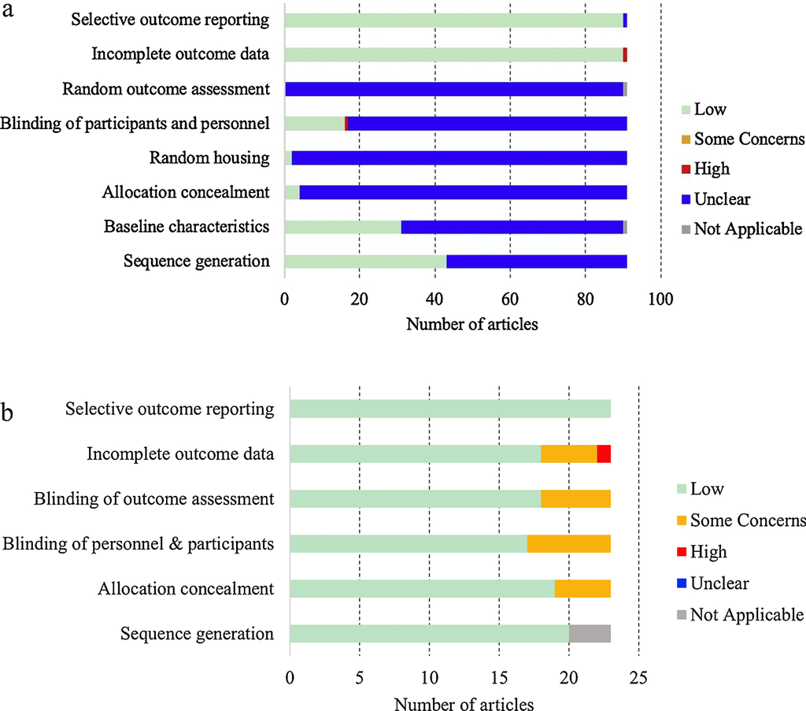

**Fig. 4.** Risk of bias for animal (a) and human (b) studies Overview of.

(a) SYRCLE risk of bias for animal studies.

(b) Cochrane risk of bias for human studies.

*B. Kioussis et al.*

*Ageing Research Reviews 67 (2021) 101302*

11

hormones from the anterior pituitary and hormones of the gastro-

enteropancreatic system (such as glucagon and insulin), and is primarily

approved for the treatment of thyrotropinomas and acromegaly (Deb-

nath and Cheriyath, 2019). Overall 1/114 studies (1 human) investi-

gated the effect of octreotide + insulin infusion, and octreotide infusion

alone on cognition in normal ageing and dementia populations. This

study (Watson et al., 2009) investigated more than one disease popu-

lation - examining one normal ageing population, and three dementia

MCI/dementia populations, for changes in cognitive outcomes. Octreo-

tide infusion may have a significant beneficial effect on cognition in

human normal ageing populations (Fig. 2). Neither octreotide + insulin

infusion nor octreotide infusion alone had a significant effect on

cognition in human MCI/dementia populations (Fig. 2).

*3.10. Animal studies only: Beta blockers, dipeptidyl peptidase (DPP)-4*

*inhibitors, melatonin, N-methyl-**D**-aspartate (NMDA) receptor antagonists,*

*Phosphodiesterase (PDE)-inhibitors, Selective serotonin reuptake inhibitors*

*(SSRIs), and statins*

These studies sometimes investigated more than one disease popu-

lation. Three out of 114 studies investigated beta blockers (four normal

ageing populations (Dobarro et al., 2013a, b, c), four dementia pop-

ulations (Dobarro et al., 2013a, b, c) including one study with a pre-

ventative model (Dobarro et al., 2013b)), 10/114 investigated DPP-4

inhibitors (four normal ageing populations (Pintana et al., 2013;

Pipatpiboon et al., 2013; Turnes et al., 2018), 19 dementia populations

(Dong et al., 2019; Hasegawa et al., 2017; Kamble et al., 2016; Khalaf

et al., 2019; Kosaraju et al., 2017, 2013; Ma et al., 2018; Pintana et al.,

2013; Pipatpiboon et al., 2013; Turnes et al., 2018)), 3/114 studies

investigated Melatonin (two normal ageing populations (Corpas et al.,

2018; Rudnitskaya et al., 2015), three dementia populations (Corpas

et al., 2018; Muhammad et al., 2019; Rudnitskaya et al., 2015)), 4/114

studies investigated NMDA receptor antagonists (six dementia pop-

ulations (Bahramian et al., 2016; Ettcheto et al., 2018; Khalaf et al.,

2019; Mietelska-Porowska et al., 2019)), 10/114 studies investigated

PDE-inhibitors (24 normal ageing populations (Barad et al., 1998; Bur-

gin et al., 2010; Cuadrado-Tejedor et al., 2011; Li et al., 2011; Orejana

et al., 2012; Rutten et al., 2008; Venkat et al., 2019), 14 dementia

populations (Burgin et al., 2010; Cuadrado-Tejedor et al., 2011; Orejana

et al., 2012; Park et al., 2011; Qi et al., 2016; Schaler and Myeku, 2018;

Venkat et al., 2019)), 3/114 studies investigated SSRI’s (two normal

ageing populations (Wu et al., 2018), two dementia populations (Ma

et al., 2017; Ren et al., 2015)), and 4/114 studies investigated statins

(four normal ageing populations (Chen et al., 2016; Fawzy Fahim et al.,

2019; Wang et al., 2015), two dementia populations (Wang et al., 2015;

Zhi et al., 2014)). Beta-blockers, DPP-4 inhibitors, Melatonin, NMDA

receptor antagonists, and statins, overall have a significantly beneficial

effect on cognition in animal therapeutic dementia populations, but not

normal ageing (Fig. 2). PDE-inhibitors and SSRI’s show benefits on

cognitive outcomes in both therapeutic dementia (including a VD model

receiving a therapeutic PDE-inhibitor (Qi et al., 2016)) and normal

ageing populations (Fig. 2). A single mouse preventative dementia

model receiving a beta-blocker as an intervention did not benefit

cognitive outcomes (Fig. 2). Significant beneficial effects on cognition

were found in normal ageing monkeys with four out of six different

therapeutic dosages of PDE-inhibitors (Rutten et al., 2008), and in

normal ageing mice populations receiving PDE-inhibitors (Barad et al.,

1998; Burgin et al., 2010; Li et al., 2011). Two normal ageing rat pop-

ulations showed a significantly positive effect of SSRI’s on cognitive

outcomes (Wu et al., 2018). These results were independent of the

method of disease induction (T2DM or otherwise), dose, duration,

sample size, cognitive domain assessed or quality of the article, and the

results for DPP-4 inhibitors, PDE-inhibitors, and SSRI’s were also inde-

pendent of the type of administered therapeutic (Fig. 4**a** and Supple-

mentary Table B.1).

*3.11. Other therapeutics and combinations*

Sixteen other nutrient sensing therapeutics were investigated for

cognitive outcomes in animals, including acarbose, an adrenoreceptor

agonist, an adenosine monophosphate-activated protein kinase (AMPK)

activator, amylin & analogues, angiotensin receptor blockers, an anti-

interleukin 1 receptor antibody, bioflavonoids, caffeine, dexibuprofen,

a gonadotropin-releasing hormone agonist, intracerebroventricular

(ICV) insulin, IGF-1, a c-Jun N-terminal kinase inhibitor, a rho-kinase

inhibitor, subcutaneous insulin, and sulfonylureas. As a cohort, these

other therapeutics have a significant beneficial effect on cognitive out-

comes in therapeutic dementia populations (Adler et al., 2014; Arendash

et al., 2009; Bahramian et al., 2016; Baraka and ElGhotny, 2010; Carro

et al., 2006; Ettcheto et al., 2017; Gibbs and Gibbs, 2013; Jiang et al.,

2008; Kitazawa et al., 2011; Kumar and Bansal, 2018; Li et al., 2018;

Moy and McNay, 2013; Ongali et al., 2014; Orejana et al., 2013; Palm

et al., 2014; Wang et al., 2014; Yan et al., 2015; Zhu et al., 2017), but not

normal ageing populations (Fig. 2) (Arendash et al., 2009; Baraka and

ElGhotny, 2010; Moy and McNay, 2013; Ongali et al., 2014; Tian et al.,

2012; Zhu et al., 2017). A single mouse preventative dementia model

receiving an angiotensin receptor blocker as an intervention exhibited

improved cognitive outcomes versus a dementia control (Fig. 2).

Five combinations of nutrient sensing therapeutics were investigated

ulations (Bahramian et al., 2016; Chen et al., 2019b; Gad et al., 2016;

Infante-Garcia et al., 2018; Khalaf et al., 2019); DPP-4 inhib-

itor/memantine (Khalaf et al., 2019), glitazone/GLP-1 agonist (Gad

et al., 2016), ICV insulin/memantine (Bahramian et al., 2016),

metformin/statin/aspirin/angiotensin-converting

enzyme

inhibitor

(Infante-Garcia et al., 2018), and metformin/GLP-1 agonist (Chen et al.,

nificant beneficial effect on cognition in animal dementia populations

(Fig. 2), although each combination was not explored in more than one

study.

*3.12. Risk of bias across studies*

Fig. 4**a** shows the SYRCLE risk of bias ratings for animal studies. The

majority of animal studies had an unclear risk of bias, as none reported

on random outcome assessment, and the majority of studies did not

report on the blinding of personnel, random housing, allocation

concealment, or baseline characteristics. The risk of bias was similar

across animal models of normal ageing, therapeutic dementia models,

provided all cognitive outcome information, although some did not

provide detailed information in cases where cognitive outcome findings

were reported to be non-significant. Overall the risk of bias was similar

across animal studies regardless of the therapeutic being tested.

Fig. 4**b** shows the Cochrane risk of bias rating for human studies.

Overall, 18/23 studies were classified as having an overall low risk bias.

Furthermore, 20/23 studies utilized randomized sequence generation,

17/23 studies were double-blinded, and 18/23 studies blinded the

outcome assessment. With regards to incomplete outcome data, 18/23

studies were of low concern. Overall the risk of bias was similar across

human studies regardless of the therapeutic being tested, with the ex-

ceptions of intranasal insulin, and insulin infusion, in which more than

half of the studies raised some concerns for bias potential in one or more

categories. Financial conflict of interest is an important possible source

of bias that is not taken into account with the Cochrane risk of bias tool.

Financial interests may be a potential bias in 7/23 studies (Gold et al.,

2010; Harrington et al., 2011; Kern et al., 2001; Luchsinger et al., 2017;

Tzimopoulou et al., 2010; Vitiello et al., 2006; Watson et al., 2019),

which either disclosed affiliations to a known pharmaceutical company

or did not provide a statement reporting any conflicts of interest.

*B. Kioussis et al.*

*Ageing Research Reviews 67 (2021) 101302*

12

For a detailed description of each article’s risk of bias refer to *Sup-*

*plementary Table D* and *Supplementary Table E*.

**4. Discussion**

Nutrient sensing-modifying therapeutics may improve ameliorate

cognitive decline in MCI or dementia populations but there is limited

evidence supporting their preventative effect for ageing populations.

Specifically, GLP-1 agonists, growth hormone secretagogues, metfor-

min, DPP-4 inhibitors and PDE-inhibitors were identified as the thera-

peutics with the most promising cognitive improvements in dementia

populations.

It has been reported that greater than 80% of patients with AD have

either T2DM or impaired fasting glucose (Janson et al., 2004), and has

been estimated to increase an individual’s risk of developing dementia

by 50% (Biessels et al., 2014), though the precise mechanism is likely to

be multi-aetiological (Verdile et al., 2015). Whilst many animal studies

utilized insulin resistant/T2DM models, this review did not note an as-

sociation between T2DM status and cognitive outcomes in animal

studies. In human studies however, with the exception of (Luchsinger

et al., 2017), no human cohorts were reported as having insulin resis-

tance or T2DM.

GLP-1 agonists and DPP-4 inhibitors, also known as incretin mi-

metics, frequently showed an improvement in cognitive outcomes in

experimental dementia models. Incretin mimetics work by mimicking

the functions of the natural incretin hormones. It has been demonstrated

that incretins can act directly upon the brain, as peripherally secreted

GLP-1 can cross the blood brain barrier (Groeneveld et al., 2016). DPP-4

inhibitors may additionally target the brain by impacting its vasculature

(Groeneveld et al., 2016). Furthermore, several *in vitro* studies have

demonstrated that incretins have neurotrophic (Faivre et al., 2011; Liu

et al., 2006; Nyberg et al., 2005; Perry et al., 2002) and neuroprotective

(Kimura et al., 2009; Liu et al., 2007, 2009; Perry et al., 2002) properties

in the brain. Importantly, studies have also demonstrated that incretins

may influence synaptic plasticity – long term potentiation (LTP) and

cognition (Gault and H¨olscher, 2008a, b; McClean et al., 2010). As such

the positive effects of GLP-1 agonists and DPP-4 inhibitors observed in

this review may be explained by a combination of mechanisms that are

neurotrophic, neuroprotective, and modulatory of synaptic plasticity.

Furthermore, whether a combination of GLP-1 agonist/DPP-4 inhibitor

could provide a synergistic increase in GLP-1 levels and improve

cognition has not yet been studied.

Similar to the incretin mimetics, growth hormones, specifically,

growth hormone secretagogues, were also likely to improve cognitive

outcomes in MCI, and dementia models. Currently there is uncertainty

around whether growth hormone elicits this cognitive effect directly,

indirectly via IGF, as a combination of the two, or through a disparate

mechanism (Devesa et al., 2018). Growth hormone may also be able to

induce and function through the local expression of IGF-1 in the brain

(Pathipati et al., 2011). There are two isoforms of IGF – IGF-1 and IGF-2

– both of which are further structurally related to proinsulin (Lewitt and

Boyd, 2019). Additionally, growth hormone secretagogues have been

shown to effectively increase IGF levels, a key constituent of the IIS

pathway (Lopez-Otin et al., 2013), whilst potentially mitigating the side

effects of direct GH administration (Sigalos and Pastuszak, 2018). The

relationship between cognition and IGF is yet to be fully understood,

although the activity of the IGF axis is well understood to decrease with

age (Williams et al., 2018). A study of healthy older men of mean age

69.1 (range 65–76) showed a significant correlation between higher

circulating levels of IGF-1 and better performance on measures of

perceptual-motor and processing speed (Aleman et al., 1999), whilst an

eight year follow-up study of 286 men of mean age 67.2 (range 48–88)

found that higher IGF-1 levels at baseline are associated with worse

future cognitive function in processing capacity and the MMSE (a

measure of global cognition) (Tumati et al., 2016). Historically, IGF-2

has only been considered to play a significant role in the central

nervous system during embryonic development (Lewitt and Boyd,

2019), due largely to its limited expression in the brain compared to

IGF-1 (Cianfarani, 2012; Lewitt and Boyd, 2019). However, whilst its

roles and molecular mechanisms through which it functions in the

central nervous system and on metabolism are still largely unknown

(Cianfarani, 2012), a prospective study exploring the associations be-

tween the various IGF’s, their binding proteins, and cognitive function

found higher circulating levels of IGF-2 are associated with better

cognitive function (Green et al., 2014). In rats and mice, IGF-2 has been

found to play a critical role in memory (Chen et al., 2011). It may be that

only optimum levels of IGF-1 in conjunction with higher circulating

IGF-2 are associated with improved long-term cognitive function – with

levels of IGF-1 too high or too low, or a deficiency of IGF-2 leading to

detriment. Additionally, ghrelin - the natural ligand of growth hormone

secretagogue receptor agonists – has been shown to increase when

fasting (Ariyasu et al., 2001). The increase in both lifespan and health-

span that results from caloric restriction has been clearly elucidated

across all studied organisms (although not yet proven in humans)

(Anderson et al., 2017b; Gems and Partridge, 2013; Mattison et al.,

2017), and despite being less studied, there is growing evidence also

indicating a positive effect of intermittent fasting on ageing (Hwangbo

et al., 2020). Because a fundamental component of the beneficial effects

of fasting are believed to be achieved through the suppression of mTOR

(Papadopoli et al., 2019), it is also possible that the mechanism through

which the potential cognitive benefits of growth hormone secretagogues

are achieved is through mimicking the effects of fasting/caloric re-

striction. Suppression of the mTOR pathway might be in general a more

effective way to reduce Aβ levels (Caccamo et al., 2010), as it is pre-

sumably over-activated in AD patients (Zhao and Townsend, 2009).

The results of our review suggest that growth hormone secretagogues

may have beneficial impacts on cognition in MCI populations, and

potentially normal ageing populations. Yet, the relationship between

IGF levels and dementia is also contentious; a meta-analysis of nine

studies identified no significant association between serum IGF-1 levels

and AD (Ostrowski et al., 2016), and a study of British men found no

association between baseline circulating IGF-1, IGF-2 and dementia risk

after 17 years of follow-up (Green et al., 2014). Furthermore, the rela-

tionship between circulating levels of IGF-binding proteins in AD pa-

tients, which may reduce the amount of bioactive IGF for a given total

serum IGF level, is poorly understood (Bonham et al., 2018; Galle et al.,

2019). It may be that the efficacy of growth hormone secretagogues is

related to the progression of dementia – that administration of these

therapeutics to individuals with MCI, before significant dampening of

IGF-signaling has occurred, could retain IGF-1 and IGF-2 levels in the

optimum range and prevent further cognitive decline (Baker et al., 2012;

Friedman et al., 2013).

Overall metformin may have some cognitive benefit in animal

models of dementia, but this did not translate to humans or normal

ageing animal models. The interplay between metformin, T2DM, and

neurodegenerative disease is complex and studies examining metformin

in these populations are often inconsistent (Wang et al., 2017). There is

evidence that metformin given in clinical settings with diabetic pop-

ulations reduces the risk of dementia (Campbell et al., 2018; Chin-Hsiao,

2019), and cognitive impairment (Ng et al., 2014). It has been hypoth-

esized metformin may act via modulation of tau, and studies examining

metformin’s neuroprotective effects have largely focused on tau levels

and Aβ production (Wang et al., 2017). While there are inconsistencies

in its effect on Aβ production (Hettich et al., 2014; Picone et al., 2015),

metformin may decrease total tau levels and phosphorylated tau

(Kickstein et al., 2010; Li et al., 2012), and may further instigate neu-

roprotection through the activation of AMPK (Wang et al., 2017). AMPK

activation may enable neuroprotection through the induction of auto-

phagy, angiogenesis, and neurogenesis (Jiang et al., 2014; Jin et al.,

2014; Poels et al., 2009; Venna et al., 2014).

The current available evidence does not support glitazones as a

beneficial therapeutic for MCI and dementia populations. However, a

longitudinal observational study (Lu et al., 2018) demonstrated a lower

incidence of dementia in populations taking pioglitazone and metfor-

min, than with other metformin-based dual therapies. This may indicate

that glitazones are effective in preventing dementia only in combination

with another therapeutic. Similarly, administration of insulin did not

appear to benefit cognitive performance. Although intranasal insulin,

which effectively bypasses the systemic circulation and blood-brain

barrier to directly enter the cerebrospinal fluid, may have some role in

improving cognition in dementia patients with shorter-term use (Dubey

et al., 2020).

In contrast to glucose-lowering therapeutics, PDE-inhibitors exhibit

their likely beneficial cognitive effect on experimental dementia models

through increasing levels of cAMP and/or cGMP (García-Osta et al.,

2012). PDE-inhibitors activate the cAMP response element-binding,

which may promote gene transcription (Impey et al., 1996; Lu et al.,

1999) that has been implicated in long-term memory formation and

persistent long-term potentiation (Tully, 1997; Yin and Tully, 1996).

This may involve the formation of new synaptic connections in the

hippocampus (Ran et al., 2012; Tully et al., 2003), and it has been

suggested that this can mitigate the cognitive impacts of dementia by

enhancing synaptic function (García-Osta et al., 2012). Further mecha-

nisms may be cognitive vasodilatory properties, and/or as a conse-

quence of emotional arousal (Reneerkens et al., 2009). As elicited by

articles

examining

normal

ageing

animals

in

this

review,

cognitive-enhancing effects of PDE-inhibitors have been observed in a

number of different normal healthy animal species (Richter et al., 2013).

Currently two phase IV clinical trials (one AD cohort, one VD cohort)

examining the effect of PDE-inhibition of cognition in humans have been

completed – no improvement in cognitive outcomes were reported for

the AD cohort (Lee et al., 2019), and the results of the VD cohort remain

unpublished.

It is possible that combinations of therapeutics may provide syner-

gistic improvements in cognitive outcomes. In this review, our search

elicited studies examining a number of therapeutic combinations in

animals. All, except the metformin/GLP-1 agonist combination,

demonstrated improvements in cognitive outcomes in dementia models.

Metformin may have a benefit in combination with glitazones (Lu et al.,

2018) and sulfonylureas (Hsu et al., 2011). Mechanistically, targeting

multiple pathways would seem to be necessary for treatment of de-

mentia, which is a complex multi-aetiological pathological entity.

Currently approved agents are limited to cholinesterase inhibitors,

memantine, or a combination of these agents, but many other thera-

peutics are currently in clinical studies as add-on therapies to the stan-

dard of care (Cummings et al., 2019).

Therapeutics classified as ‘Other’ were not investigated in any

human population and were examined in *<*3 studies in animals, thus

making it difficult to draw tenable conclusions relating to their efficacy

in human normal ageing and dementia populations. Some of the more

promising ‘other’ therapeutics included in this review are amylin &

analogues, caffeine, ICV insulin, and subcutaneous insulin. Our search of

registered human trials found a number of ‘other’ therapeutics currently

being investigated, including melatonin, statins, adrenoreceptor ago-

nists, and angiotensin receptor blockers.

There has consistently been a poor translation of successful thera-

peutics of pre-clinical animal dementia models to successful in-

terventions

in

human

dementia

clinical

trials

(Franco

and

Cedazo-Minguez, 2014). Aspects such as the wide range of animal de-

mentia models available, the questionable accuracy of these in

mimicking human age-related dementia, and differences in study design

between animal and human studies, must presumably all contribute to

this lack of translation. The majority of animal dementia models utilized

by studies in this review were transgenic, overexpressing or producing

mutant products of human genes such as amyloid precursor protein

(APP), tau, and presenilin 1 (PS1). However, a wide variety of other

dementia models were also utilized, such as administration of ICV Aβ or

streptozotocin. It remains contentious how extrapolatable findings are

from animal models such as these, which are at best incomplete repre-

sentations of a complex multi-aetiological disease process – an example

being that transgenic models do not fully recapitulate neuronal loss

(Elder et al., 2010) which is a fundamental pathological mechanism of

dementia (Moya-Alvarado et al., 2016). Although human interventional

trials are often carried out for a much shorter portion of time relative to

the individual’s lifespan than in animal trials, the longer duration of

animal trials are often carried out using a much smaller number of an-

imals. In the future, animal studies may more clearly define the de-

mentia model’s baseline level of cognition, and their own aims of

exploring interventions as being either neuroprotective, cognitive

enhancing, or disease-modifying agent, to help discriminate the various

modes by which successful pre-clinical interventions may be having

their effect.

*4.1. Limitations*

Our search strategy was based primarily on key terms related to the

main nutrient sensing pathways, with the addition of a selection of

therapeutics well-known to modulate these processes. Therefore, our

search may have missed studies that examine drugs that modulate

nutrient sensing not named in our search and not mentioning nutrient

sensing pathway or related key terms. Secondly, whilst the therapeutics

included in this review have had prior FDA approval, certain specific

administration methods of these therapeutics have not; namely intra-

nasal insulin, insulin infusion, octreotide infusion, and combination

insulin infusion + octreotide infusion. Thirdly, we cannot exclude

publication bias, particularly in animal studies which are unlikely to be

registered and may be less likely to be published if results are negative.

Fourth, we did not perform any formal statistical analysis and results are

based on reported p-values. The significance of p-values is influenced by

sample size. This is likely to have impacted our findings as the majority

of animal studies included in this review had a low sample size

(n≤10–15, with n = 5 for some mouse studies), and 11/23 human

studies utilized human populations with *<*15 individuals. The small

sample size of these studies specifically, the animal studies is a wide-

spread structural problem within animal research. Studies with small

sample sizes are likely to produce ambiguous or misleading results as

smaller numbers can inflate the effect size. Ensuring experiments use

appropriate sample sizes are critical for reproducibility of findings and

future animal research should focus on utilizing power calculation to

ensure the appropriate number of animals are included in all treatment

arms. Fifth, due to the variation in reported data - different; animal

models, FDA therapeutics, dosages, duration of treatment, length of

study and control groups - a meta-analysis reporting overall effects on

cognition could not be performed. Sixth, whilst the age of animals was

largely consistent, mice utilized as preventative and therapeutic de-

mentia models may have been slightly younger than normal ageing

models. Finally, this review has also identified some reporting omissions

within this research field. Specifically, the use of the SYRCLE bias tool

has highlighted large gaps in reporting of the trial design in animal

studies. Aspects such as random outcome assessment, blinding of

personnel, random housing, allocation concealment, baseline charac-

teristics, and sequence generation, was often unclear. Future animal

trials should consider following the SYRCLE guidelines (Hooijmans

et al., 2014).

**5. Conclusions**

The results of this review indicate that nutrient sensing-modifying

therapeutics have the potential to alter cognitive outcomes in MCI or

dementia populations. Overall, the translation of therapeutic efficacy

from animal models to human populations is limited. Further studies are

required to fully elucidate the potential of GLP-1 agonists, growth hor-

mone secretagogues, metformin, DPP-4 inhibitors, and PDE-inhibitors in

dementia.

**Acknowledgements**

An unrestricted grant by the University of Melbourne supported the

work. We thank Patrick Condron from the Brownless Biomedical Li-

brary, University of Melbourne, for his assistance with the search

strategy.

**Appendix A. Supplementary data**

Supplementary material related to this article can be found, in the

online version, at doi:https://doi.org/10.1016/j.arr.2021.101302.

**References**

Adler, B.L., Yarchoan, M., Hwang, H.M., Louneva, N., Blair, J.A., Palm, R., Smith, M.A.,

Lee, H.G., Arnold, S.E., Casadesus, G., 2014. Neuroprotective effects of the amylin

analogue pramlintide on Alzheimer’s disease pathogenesis and cognition. Neurobiol.

Aging 35, 793–801.

Ahmed, S., Mahmood, Z., Javed, A., Hashmi, S.N., Zerr, I., Zafar, S., Zahid, S., 2017.

Effect of metformin on adult hippocampal neurogenesis: comparison with donepezil

and links to cognition. J. Mol. Neurosci. 62, 88–98.

Akintola, A.A., van Heemst, D., 2015. Insulin, aging, and the brain: mechanisms and

implications. Front. Endocrinol. (Lausanne) 6, 13-13.

Aleman, A., Verhaar, H.J., De Haan, E.H., De Vries, W.R., Samson, M.M., Drent, M.L.,

Van der Veen, E.A., Koppeschaar, H.P., 1999. Insulin-like growth factor-I and

cognitive function in healthy older men. J. Clin. Endocrinol. Metab. 84, 471–475.

Allard, J.S., Perez, E.J., Fukui, K., Carpenter, P., Ingram, D.K., de Cabo, R., 2016.

Prolonged metformin treatment leads to reduced transcription of Nrf2 and

neurotrophic factors without cognitive impairment in older C57BL/6J mice. Behav.

Brain Res. 301, 1–9.

Anderson, K.L., Frazier, H.N., Maimaiti, S., Bakshi, V.V., Majeed, Z.R., Brewer, L.D.,

Porter, N.M., Lin, A.L., Thibault, O., 2017a. Impact of single or repeated dose

intranasal zinc-free insulin in young and aged F344 rats on cognition, signaling, and

brain metabolism. J. Gerontol. A Biol. Sci. Med. Sci. 72, 189–197.

Anderson, R.M., Le Couteur, D.G., de Cabo, R., 2017b. Caloric restriction research: new

perspectives on the biology of aging. J. Gerontol. A Biol. Sci. Med. Sci. 73, 1–3.

Arendash, G.W., Mori, T., Cao, C., Mamcarz, M., Runfeldt, M., Dickson, A., Rezai-

Zadeh, K., Tane, J., Citron, B.A., Lin, X., Echeverria, V., Potter, H., 2009. Caffeine

reverses cognitive impairment and decreases brain amyloid-beta levels in aged

Alzheimer’s disease mice. J. Alzheimers Dis. 17, 661–680.

Ariyasu, H., Takaya, K., Tagami, T., Ogawa, Y., Hosoda, K., Akamizu, T., Suda, M.,

Koh, T., Natsui, K., Toyooka, S., Shirakami, G., Usui, T., Shimatsu, A., Doi, K.,

Hosoda, H., Kojima, M., Kangawa, K., Nakao, K., 2001. Stomach is a major source of

circulating ghrelin, and feeding state determines plasma ghrelin-like

immunoreactivity levels in humans. J. Clin. Endocrinol. Metab. 86, 4753–4758.

Australian Medicines Handbook Pty Ltd., Australian medicines handbook. Australian

Medicines Handbook. Adelaide, S.Aust.

Bahramian, A., Rastegar, K., Namavar, M.R., Moosavi, M., 2016. Insulin potentiates the

therapeutic effect of memantine against central STZ-induced spatial learning and

memory deficit. Behav. Brain Res. 311, 247–254.

Baker, L.D., Barsness, S.M., Borson, S., Merriam, G.R., Friedman, S.D., Craft, S.,

Vitiello, M.V., 2012. Effects of growth hormone-releasing hormone on cognitive

function in adults with mild cognitive impairment and healthy older adults: results

of a controlled trial. Arch. Neurol. 69, 1420–1429.

Barad, M., Bourtchouladze, R., Winder, D.G., Golan, H., Kandel, E., 1998. Rolipram, a

type IV-specific phosphodiesterase inhibitor, facilitates the establishment of long-

lasting long-term potentiation and improves memory. Proc. Natl. Acad. Sci. U.S.A.

95, 15020–15025.

Baraka, A., ElGhotny, S., 2010. Study of the effect of inhibiting galanin in Alzheimer’s

disease induced in rats. Eur. J. Pharmacol. 641, 123–127.

Bell, G.A., Fadool, D.A., 2017. Awake, long-term intranasal insulin treatment does not

affect object memory, odor discrimination, or reversal learning in mice. Physiol.

Behav. 174, 104–113.

Biessels, G.J., Strachan, M.W.J., Visseren, F.L.J., Kappelle, L.J., Whitmer, R.A., 2014.

Dementia and cognitive decline in type 2 diabetes and prediabetic stages: towards

targeted interventions. Lancet Diabetes Endocrinol. 2, 246–255.

Bomba, M., Ciavardelli, D., Silvestri, E., Canzoniero, L.M., Lattanzio, R., Chiappini, P.,

Piantelli, M., Di Ilio, C., Consoli, A., Sensi, S.L., 2013. Exenatide promotes cognitive

enhancement and positive brain metabolic changes in PS1-KI mice but has no effects

in 3xTg-AD animals. Cell Death Dis. 4, e612.

Bomfim, T.R., Forny-Germano, L., Sathler, L.B., Brito-Moreira, J., Houzel, J.C.,

Decker, H., Silverman, M.A., Kazi, H., Melo, H.M., McClean, P.L., Holscher, C.,

Arnold, S.E., Talbot, K., Klein, W.L., Munoz, D.P., Ferreira, S.T., De Felice, F.G.,

2012. An anti-diabetes agent protects the mouse brain from defective insulin

signaling caused by Alzheimer’s disease- associated Abeta oligomers. J. Clin. Invest.

122, 1339–1353.

Bonham, L.W., Geier, E.G., Steele, N.Z.R., Holland, D., Miller, B.L., Dale, A.M.,

Desikan, R.S., Yokoyama, J.S., A.s.D.N.I, 2018. Insulin-like growth factor binding

protein 2 is associated with biomarkers of alzheimer’s disease pathology and shows

differential expression in transgenic mice. Front. Neurosci. 12.

Brooks, A.J., Waters, M.J., 2010. The growth hormone receptor: mechanism of activation

and clinical implications. Nat. Rev. Endocrinol. 6, 515–525.

Burgin, A.B., Magnusson, O.T., Singh, J., Witte, P., Staker, B.L., Bjornsson, J.M.,

Thorsteinsdottir, M., Hrafnsdottir, S., Hagen, T., Kiselyov, A.S., Stewart, L.J.,

Gurney, M.E., 2010. Design of phosphodiesterase 4D (PDE4D) allosteric modulators

for enhancing cognition with improved safety. Nat. Biotechnol. 28, 63–70.

Caccamo, A., Majumder, S., Richardson, A., Strong, R., Oddo, S., 2010. Molecular

interplay between mammalian target of rapamycin (mTOR), amyloid-beta, and Tau:

effects on cognitive impairments. J. Biol. Chem. 285, 13107–13120.

Campbell, J.M., Stephenson, M.D., de Courten, B., Chapman, I., Bellman, S.M.,

Aromataris, E., 2018. Metformin use associated with reduced risk of dementia in

patients with diabetes: a systematic review and meta-analysis. J. Alzheimers Dis. 65,

1225–1236.

Carro, E., Trejo, J.L., Gerber, A., Loetscher, H., Torrado, J., Metzger, F., Torres-

Aleman, I., 2006. Therapeutic actions of insulin-like growth factor I on APP/PS2

mice with severe brain amyloidosis. Neurobiol. Aging 27, 1250–1257.

Chen, D.Y., Stern, S.A., Garcia-Osta, A., Saunier-Rebori, B., Pollonini, G., Bambah-

Mukku, D., Blitzer, R.D., Alberini, C.M., 2011. A critical role for IGF-II in memory

consolidation and enhancement. Nature 469, 491–497.

Chen, T., Wang, C., Sha, S., Zhou, L., Chen, L., Chen, L., 2016. Simvastatin enhances

spatial memory and long-term potentiation in hippocampal CA1 via Upregulation of

alpha7 nicotinic acetylcholine receptor. Mol. Neurobiol. 53, 4060–4072.

Chen, J.L., Luo, C., Pu, D., Zhang, G.Q., Zhao, Y.X., Sun, Y., Zhao, K.X., Liao, Z.Y., Lv, A.

K., Zhu, S.Y., Zhou, J., Xiao, Q., 2019a. Metformin attenuates diabetes-induced tau

hyperphosphorylation in vitro and in vivo by enhancing autophagic clearance. Exp.

Neurol. 311, 44–56.

Chen, S., Tang, Q., Wang, Y., Xu, Z., Chen, S.T., Sun, Y., Yao, W.B., Gao, X.D., 2019b.

Evidence of metabolic memory-induced neurodegeneration and the therapeutic

effects of glucagon-like peptide-1 receptor agonists via Forkhead box class O.

Biochim. Biophys. Acta Mol. Basis Dis. 1865, 371–377.

Chin-Hsiao, T., 2019. Metformin and the risk of dementia in type 2 diabetes patients.

Aging Dis. 10, 37–48.

Cianfarani, S., 2012. Insulin-like growth factor-II: new roles for an old actor. Front.

Endocrinol. (Lausanne) 3.

Claxton, A., Baker, L.D., Wilkinson, C.W., Trittschuh, E.H., Chapman, D., Watson, G.S.,

Cholerton, B., Plymate, S.R., Arbuckle, M., Craft, S., 2013. Sex and ApoE genotype

differences in treatment response to two doses of intranasal insulin in adults with

mild cognitive impairment or Alzheimer’s disease. J. Alzheimers Dis. 35, 789–797.

Claxton, A., Baker, L.D., Hanson, A., Trittschuh, E.H., Cholerton, B., Morgan, A.,

Callaghan, M., Arbuckle, M., Behl, C., Craft, S., 2015. Long acting intranasal insulin

detemir improves cognition for adults with mild cognitive impairment or early-stage

alzheimer’s disease dementia. J. Alzheimers Dis. 45, 1269–1270.

Collins, L., Costello, R.A., 2019. Glucagon-like Peptide-1 Receptor Agonists.

Corcoran, C., Jacobs, T.F., 2018. Metformin, StatPearls [Internet]. StatPearls Publishing.

Corpas, R., Gri˜n´an-Ferr´e, C., Palomera-<sup>´</sup>Avalos, V., Porquet, D., García de Frutos, P.,

Franciscato Cozzolino, S.M., Rodríguez-Farr´e, E., Pall`as, M., Sanfeliu, C., Cardoso, B.

R., 2018. Melatonin induces mechanisms of brain resilience against

neurodegeneration. J. Pineal Res. 65, e12515.

Craft, S., Baker, L.D., Montine, T.J., Minoshima, S., Watson, G.S., Claxton, A.,

Arbuckle, M., Callaghan, M., Tsai, E., Plymate, S.R., Green, P.S., Leverenz, J.,

Cross, D., Gerton, B., 2012. Intranasal insulin therapy for Alzheimer disease and

amnestic mild cognitive impairment: a pilot clinical trial. Arch. Neurol. 69, 29–38.

Craft, S., Claxton, A., Baker, L.D., Hanson, A.J., Cholerton, B., Trittschuh, E.H., Dahl, D.,

Caulder, E., Neth, B., Montine, T.J., Jung, Y., Maldjian, J., Whitlow, C., Friedman, S.,

2017. Effects of regular and long-acting insulin on cognition and alzheimer’s disease

biomarkers: a pilot clinical trial. J. Alzheimers Dis. 57, 1325–1334.

Cuadrado-Tejedor, M., Hervias, I., Ricobaraza, A., Puerta, E., Perez-Roldan, J.M., Garcia-

Barroso, C., Franco, R., Aguirre, N., Garcia-Osta, A., 2011. Sildenafil restores

cognitive function without affecting beta-amyloid burden in a mouse model of

Alzheimer’s disease. Br. J. Pharmacol. 164, 2029–2041.

Cummings, J.L., Tong, G., Ballard, C., 2019. Treatment combinations for alzheimer’s

disease: current and future pharmacotherapy options. J. Alzheimers Dis. 67,

779–794.

de la Monte, S.M., 2013. Intranasal insulin therapy for cognitive impairment and

neurodegeneration: current state of the art. Expert Opin. Drug Deliv. 10, 1699–1709.

Debnath, D., Cheriyath, P., 2019. Octreotide, StatPearls [Internet]. StatPearls Publishing.

Denner, L.A., Rodriguez-Rivera, J., Haidacher, S.J., Jahrling, J.B., Carmical, J.R.,

Hernandez, C.M., Zhao, Y., Sadygov, R.G., Starkey, J.M., Spratt, H., Luxon, B.A.,

Wood, T.G., Dineley, K.T., 2012. Cognitive enhancement with rosiglitazone links the

hippocampal PPARgamma and ERK MAPK signaling pathways. J. Neurosci. 32,

16725–16735a.

Devesa, J., Nú˜nez, I., Agra, C., Bejarano, A., Devesa, P., 2018. Treatment with Growth

Hormone (GH) Increased the Metabolic Activity of the Brain in an Elder Patient, Not

GH-Deficient, Who Suffered Mild Cognitive Alterations and Had an ApoE 4/3

Genotype. Int. J. Mol. Sci. 19, 2294.

Dobarro, M., Gerenu, G., Ramirez, M.J., 2013a. Propranolol reduces cognitive deficits,

amyloid and tau pathology in Alzheimer’s transgenic mice. Int. J.

Neuropsychopharmacol. 16, 2245–2257.

Dobarro, M., Orejana, L., Aguirre, N., Ramirez, M.J., 2013b. Propranolol reduces

cognitive deficits, amyloid beta levels, tau phosphorylation and insulin resistance in

response to chronic corticosterone administration. Int. J. Neuropsychopharmacol.

16, 1351–1360.

Dobarro, M., Orejana, L., Aguirre, N., Ramirez, M.J., 2013c. Propranolol restores

cognitive deficits and improves amyloid and Tau pathologies in a senescence-

accelerated mouse model. Neuropharmacology 64, 137–144.

Dong, Q., Teng, S.W., Wang, Y., Qin, F., Li, Y., Ai, L.L., Yu, H., 2019. Sitagliptin protects

the cognition function of the Alzheimer’s disease mice through activating glucagon-

like peptide-1 and BDNF-TrkB signalings. Neurosci. Lett. 696, 184–190.

Dubey, S.K., Lakshmi, K.K., Krishna, K.V., Agrawal, M., Singhvi, G., Saha, R.N., Saraf, S.,

Saraf, S., Shukla, R., Alexander, A., 2020. Insulin mediated novel therapies for the

treatment of Alzheimer’s disease. Life Sci. 249, 117540.

Dugger, B.N., Dickson, D.W., 2017. Pathology of neurodegenerative diseases. Cold Spring

Harb. Perspect. Biol. 9.

Eggleton, J.S., Jialal, I., 2019. Thiazolidinediones, StatPearls [Internet]. StatPearls

Publishing.

Elder, G.A., Gama Sosa, M.A., De Gasperi, R., 2010. Transgenic mouse models of

Alzheimer’s disease. Mt. Sinai J. Med. 77, 69–81.

Ettcheto, M., S´anchez-L´opez, E., Pons, L., Busquets, O., Olloquequi, J., Beas-Zarate, C.,

Pallas, M., García, M.L., Auladell, C., Folch, J., Camins, A., 2017. Dexibuprofen

prevents neurodegeneration and cognitive decline in APPswe/PS1dE9 through

multiple signaling pathways. Redox Biol. 13, 345–352.

Ettcheto, M., S´anchez-L´opez, E., G´omez-Mínguez, Y., Cabrera, H., Busquets, O., Beas-

Zarate, C., García, M.L., Carro, E., Casadesus, G., Auladell, C., V´azquez Carrera, M.,

Folch, J., Camins, A., 2018. Peripheral and central effects of memantine in a mixed

preclinical mice model of obesity and familial alzheimer’s disease. Mol. Neurobiol.

55, 7327–7339.

Faivre, E., Gault, V.A., Thorens, B., H¨olscher, C., 2011. Glucose-dependent insulinotropic

polypeptide receptor knockout mice are impaired in learning, synaptic plasticity,

and neurogenesis. J. Neurophysiol. 105, 1574–1580.

Fawzy Fahim, V., Wadie, W., Shafik, A.N., Ishak Attallah, M., 2019. Role of simvastatin

and insulin in memory protection in a rat model of diabetes mellitus and dementia.

Brain Res. Bull. 144, 21–27.

Fidaleo, M., Cavallucci, V., Pani, G., 2017. Nutrients, neurogenesis and brain ageing:

from disease mechanisms to therapeutic opportunities. Biochem. Pharmacol. 141,

63–76.

Fluegge, K., 2019. A model of lipid dysregulation and altered nutrient status in

Alzheimer’s disease. Alzheimers Dement. N. Y. (N Y) 5, 139–145.

Franco, R., Cedazo-Minguez, A., 2014. Successful therapies for Alzheimer’s disease: why

so many in animal models and none in humans? Front. Pharmacol. 5, 146-146.

Friedman, S.D., Baker, L.D., Borson, S., Jensen, J.E., Barsness, S.M., Craft, S., Merriam, G.

R., Otto, R.K., Novotny, E.J., Vitiello, M.V., 2013. Growth hormone-releasing

hormone effects on brain gamma-aminobutyric acid levels in mild cognitive

impairment and healthy aging. JAMA Neurol. 70, 883–890.

Gad, E.S., Zaitone, S.A., Moustafa, Y.M., 2016. Pioglitazone and exenatide enhance

cognition and downregulate hippocampal beta amyloid oligomer and microglia

expression in insulin-resistant rats. Can. J. Physiol. Pharmacol. 94, 819–828.

Galle, S.A., van der Spek, A., Drent, M.L., Brugts, M.P., Scherder, E.J.A., Janssen, J.A.M.

J.L., Ikram, M.A., van Duijn, C.M., 2019. Revisiting the role of insulin-like growth

Factor-I receptor stimulating activity and the apolipoprotein e in alzheimer’s

disease. Front. Aging Neurosci. 11.

Gao, C., Wang, Q., Chung, S.K., Shen, J., 2017. Crosstalk of metabolic factors and

neurogenic signaling in adult neurogenesis: implication of metabolic regulation for

mental and neurological diseases. Neurochem. Int. 106, 24–36.

García-Osta, A., Cuadrado-Tejedor, M., García-Barroso, C., Oyarz´abal, J., Franco, R.,

2012. Phosphodiesterases as therapeutic targets for Alzheimer’s disease. ACS Chem.

Neurosci. 3, 832–844.

Gault, V.A., H¨olscher, C., 2008a. GLP-1 agonists facilitate hippocampal LTP and reverse

the impairment of LTP induced by beta-amyloid. Eur. J. Pharmacol. 587, 112–117.

Gault, V.A., H¨olscher, C., 2008b. Protease-resistant glucose-dependent insulinotropic

polypeptide agonists facilitate hippocampal LTP and reverse the impairment of LTP

induced by beta-amyloid. J. Neurophysiol. 99, 1590–1595.

Gejl, M., Gjedde, A., Egefjord, L., Moller, A., Hansen, S.B., Vang, K., Rodell, A.,

Braendgaard, H., Gottrup, H., Schacht, A., Moller, N., Brock, B., Rungby, J., 2016. In

alzheimer’s disease, 6-Month treatment with GLP-1 analog prevents decline of brain

glucose metabolism: randomized, placebo-controlled, double-blind clinical trial.

Front. Aging Neurosci. 8, 108.

Gems, D., Partridge, L., 2013. Genetics of longevity in model organisms: debates and

paradigm shifts. Annu. Rev. Physiol. 75, 621–644.

George, K., Woollett, G., 2019. Insulins as Drugs or Biologics in the USA: What Difference

Does it Make and Why Does it Matter? BioDrugs 33, 447–451.

Gibbs, M.E., Gibbs, C.L., 2013. Deleterious effects of soluble beta amyloid on cognition,

antagonism by saline and noradrenaline, a role for microglia. Neuroscience 230,

62–71.

Gold, M., Alderton, C., Zvartau-Hind, M., Egginton, S., Saunders, A.M., Irizarry, M.,

Craft, S., Landreth, G., Linnamagi, U., Sawchak, S., 2010. Rosiglitazone

monotherapy in mild-to-Moderate alzheimer’s disease: results from a randomized,

double-blind, placebo-controlled phase III study. Dement. Geriatr. Cogn. Disord. 30,

131–146.

Green, C.J., Holly, J.M., Bayer, A., Fish, M., Ebrahim, S., Gallacher, J., Ben-Shlomo, Y.,

2014. The role of IGF-I, IGF-II, and IGFBP-3 in male cognitive aging and dementia

risk: the Caerphilly Prospective Study. J. Alzheimer Dis. 41, 867–875.

Grieb, P., 2016. Intracerebroventricular streptozotocin injections as a model of

alzheimer’s disease: in search of a relevant mechanism. Mol. Neurobiol. 53,

1741–1752.

Griffin, R.J., Moloney, A., Kelliher, M., Johnston, J.A., Ravid, R., Dockery, P.,

O’Connor, R., O’Neill, C., 2005. Activation of Akt/PKB, increased phosphorylation of

Akt substrates and loss and altered distribution of Akt and PTEN are features of

Alzheimer’s disease pathology. J. Neurochem. 93, 105–117.

Groeneveld, O.N., Kappelle, L.J., Biessels, G.J., 2016. Potentials of incretin-based

therapies in dementia and stroke in type 2 diabetes mellitus. J. Diabetes Investig. 7,

5–16.

Gumuslu, E., Mutlu, O., Celikyurt, I.K., Ulak, G., Akar, F., Erden, F., Ertan, M., 2016.

Exenatide enhances cognitive performance and upregulates neurotrophic factor gene

expression levels in diabetic mice. Fundam. Clin. Pharmacol. 30, 376–384.

Guo, Z., Chen, Y., Mao, Y.-F., Zheng, T., Jiang, Y., Yan, Y., Yin, X., Zhang, B., 2017. Long-

term treatment with intranasal insulin ameliorates cognitive impairment, tau

hyperphosphorylation, and microglial activation in a streptozotocin-induced

Alzheimer’s rat model. Sci. Rep. 7, 45971.

Harrington, C., Sawchak, S., Chiang, C., Davies, J., Donovan, C., Saunders, A.M.,

Irizarry, M., Jeter, B., Zvartau-Hind, M., van Dyck, C.H., Gold, M., 2011.

Rosiglitazone does not improve cognition or global function when used as adjunctive

therapy to AChE inhibitors in mild-to-Moderate alzheimer’s disease: two phase 3

studies. Curr. Alzheimer Res. 8, 592–606.

Hasegawa, Y., Hayashi, K., Takemoto, Y., Cheng, C., Takane, K., Lin, B., Komohara, Y.,

Kim-Mitsuyama, S., 2017. DPP-4 inhibition with linagliptin ameliorates the

progression of premature aging in klotho−/− mice. Cardiovasc. Diabetol. 16, 154.

Heard, D.S., Tuttle, C.S.L., Lautenschlager, N.T., Maier, A.B., 2018. Repurposing

proteostasis-modifying drugs to prevent or treat age-related dementia: a systematic

review. Front. Physiol. 9, 1520.

Hettich, M.M., Matthes, F., Ryan, D.P., Griesche, N., Schr¨oder, S., Dorn, S., Krauβ, S.,

Ehninger, D., 2014. The anti-diabetic drug metformin reduces BACE1 protein level

by interfering with the MID1 complex. PLoS One 9, e102420.

Higgins, J.P.T., Altman, D.G., Gøtzsche, P.C., Jüni, P., Moher, D., Oxman, A.D.,

Savovi´c, J., Schulz, K.F., Weeks, L., Sterne, J.A.C., 2011. The Cochrane

Collaboration’s tool for assessing risk of bias in randomised trials. BMJ 343, d5928.

Hooijmans, C.R., Rovers, M.M., de Vries, R.B.M., Leenaars, M., Ritskes-Hoitinga, M.,

Langendam, M.W., 2014. SYRCLE’s risk of bias tool for animal studies. BMC Med.

Res. Methodol. 14, 43.

Hsu, C.-C., Wahlqvist, M.L., Lee, M.-S., Tsai, H.-N., 2011. Incidence of dementia is

increased in type 2 diabetes and reduced by the use of sulfonylureas and metformin.

J. Alzheimer Dis. 24, 485–493.

Huang, H.J., Chen, Y.H., Liang, K.C., Jheng, Y.S., Jhao, J.J., Su, M.T., Lee-Chen, G.J.,

Hsieh-Li, H.M., 2012. Exendin-4 protected against cognitive dysfunction in

hyperglycemic mice receiving an intrahippocampal lipopolysaccharide injection.

PLoS One 7, e39656.

Hwangbo, D.-S., Lee, H.-Y., Abozaid, L.S., Min, K.-J., 2020. Mechanisms of lifespan

regulation by calorie restriction and intermittent fasting in model organisms.

Nutrients 12, 1194.

Impey, S., Mark, M., Villacres, E.C., Poser, S., Chavkin, C., Storm, D.R., 1996. Induction

of CRE-mediated gene expression by stimuli that generate long-lasting LTP in area

CA1 of the hippocampus. Neuron 16, 973–982.

Infante-Garcia, C., Ramos-Rodriguez, J.J., Hierro-Bujalance, C., Ortegon, E., Pickett, E.,

Jackson, R., Hernandez-Pacho, F., Spires-Jones, T., Garcia-Alloza, M., 2018.

Antidiabetic polypill improves central pathology and cognitive impairment in a

mixed model of alzheimer’s disease and type 2 diabetes. Mol. Neurobiol. 55,

6130–6144.

Isacson, R., Nielsen, E., Dannaeus, K., Bertilsson, G., Patrone, C., Zachrisson, O.,

Wikstrom, L., 2011. The glucagon-like peptide 1 receptor agonist exendin-4

improves reference memory performance and decreases immobility in the forced

swim test. Eur. J. Pharmacol. 650, 249–255.

Ishida, J., Saitoh, M., Ebner, N., Springer, J., Anker, S.D., von Haehling, S., 2020. Growth

hormone secretagogues: history, mechanism of action, and clinical development.

JCSM Rapid Commun. 3, 25–37.

Jahrling, J.B., Laberge, R.-M., 2015. Age-related neurodegeneration prevention through

mTOR inhibition: potential mechanisms and remaining questions. Curr. Top. Med.

Chem. 15, 2139–2151.

Janson, J., Laedtke, T., Parisi, J.E., O’Brien, P., Petersen, R.C., Butler, P.C., 2004.

Increased risk of type 2 diabetes in alzheimer disease. Diabetes 53, 474.

Jiang, L.H., Zhang, Y.N., Wu, X.W., Song, F.F., Guo, D.Y., 2008. Effect of insulin on the

cognizing function and expression of hippocampal Abeta1-40 of rat with Alzheimer

disease. Chin. Med. J. 121, 827–831.

Jiang, L.Y., Tang, S.S., Wang, X.Y., Liu, L.P., Long, Y., Hu, M., Liao, M.X., Ding, Q.L.,

Hu, W., Li, J.C., Hong, H., 2012. PPAR? Agonist pioglitazone reverses memory

impairment and biochemical changes in a mouse model of type 2 diabetes mellitus.

CNS Neurosci. Ther. 18, 659–666.

Jiang, T., Yu, J.T., Zhu, X.C., Wang, H.F., Tan, M.S., Cao, L., Zhang, Q.Q., Gao, L., Shi, J.

Q., Zhang, Y.D., Tan, L., 2014. Acute metformin preconditioning confers

neuroprotection against focal cerebral ischaemia by pre-activation of AMPK-

dependent autophagy. Br. J. Pharmacol. 171, 3146–3157.

Jin, Q., Cheng, J., Liu, Y., Wu, J., Wang, X., Wei, S., Zhou, X., Qin, Z., Jia, J., Zhen, X.,

2014. Improvement of functional recovery by chronic metformin treatment is

associated with enhanced alternative activation of microglia/macrophages and

increased angiogenesis and neurogenesis following experimental stroke. Brain

Behav. Immun. 40, 131–142.

Kamble, M., Gupta, R., Rehan, H.S., Gupta, L.K., 2016. Neurobehavioral effects of

liraglutide and sitagliptin in experimental models. Eur. J. Pharmacol. 774, 64–70.

Kern, W., Peters, A., Fruehwald-Schultes, B., Deininger, E., Born, J., Fehm, H.L., 2001.

Improving influence of insulin on cognitive functions in humans.

Neuroendocrinology 74, 270–280.

Khalaf, S.S., Hafez, M.M., Mehanna, E.T., Mesbah, N.M., Abo-Elmatty, D.M., 2019.

Combined vildagliptin and memantine treatment downregulates expression of

amyloid precursor protein, and total and phosphorylated tau in a rat model of

combined Alzheimer’s disease and type 2 diabetes. Naunyn Schmiedebergs Arch.

Pharmacol. 392, 685–695.

Kickstein, E., Krauss, S., Thornhill, P., Rutschow, D., Zeller, R., Sharkey, J.,

Williamson, R., Fuchs, M., K¨ohler, A., Glossmann, H., Schneider, R., Sutherland, C.,

Schweiger, S., 2010. Biguanide metformin acts on tau phosphorylation via mTOR/

protein phosphatase 2A (PP2A) signaling. Proc. Natl. Acad. Sci. U S A 107,

21830–21835.

Kimura, R., Okouchi, M., Fujioka, H., Ichiyanagi, A., Ryuge, F., Mizuno, T., Imaeda, K.,

Okayama, N., Kamiya, Y., Asai, K., Joh, T., 2009. Glucagon-like peptide-1 (GLP-1)

protects against methylglyoxal-induced PC12 cell apoptosis through the PI3K/Akt/

mTOR/GCLc/redox signaling pathway. Neuroscience 162, 1212–1219.

Kitazawa, M., Cheng, D., Tsukamoto, M.R., Koike, M.A., Wes, P.D., Vasilevko, V.,

Cribbs, D.H., LaFerla, F.M., 2011. Blocking IL-1 signaling rescues cognition,

attenuates tau pathology, and restores neuronal beta-catenin pathway function in an

Alzheimer’s disease model. J. Immunol. 187, 6539–6549.

Kosaraju, J., Murthy, V., Khatwal, R.B., Dubala, A., Chinni, S., Muthureddy Nataraj, S.K.,

Basavan, D., 2013. Vildagliptin: an anti-diabetes agent ameliorates cognitive deficits

and pathology observed in streptozotocin-induced Alzheimer’s disease. J. Pharm.

Pharmacol. 65, 1773–1784.

Kosaraju, J., Holsinger, R.M.D., Guo, L., Tam, K.Y., 2017. Linagliptin, a dipeptidyl

Peptidase-4 inhibitor, mitigates cognitive deficits and pathology in the 3xTg-AD

mouse model of alzheimer’s disease. Mol. Neurobiol. 54, 6074–6084.

Kumar, M., Bansal, N., 2018. Fasudil hydrochloride ameliorates memory deficits in rat

model of streptozotocin-induced Alzheimer’s disease: involvement of PI3-kinase,

eNOS and NFκB. Behav. Brain Res. 351, 4–16.

Kummer, M.P., Schwarzenberger, R., Sayah-Jeanne, S., Dubernet, M., Walczak, R.,

Hum, D.W., Schwartz, S., Axt, D., Heneka, M.T., 2015. Pan-PPAR modulation

effectively protects APP/PS1 mice from amyloid deposition and cognitive deficits.

Mol. Neurobiol. 51, 661–671.

Kunath, N., van Groen, T., Allison, D.B., Kumar, A., Dozier-Sharpe, M., Kadish, I., 2015.

Ghrelin agonist does not foster insulin resistance but improves cognition in an

Alzheimer’s disease mouse model. Sci. Rep. 5, 11452.

Lee, J.Y., Lee, H., Yoo, H.B., Choi, J.S., Jung, H.Y., Yoon, E.J., Kim, H., Jung, Y.H.,

Lee, H.Y., Kim, Y.K., 2019. Efficacy of cilostazol administration in alzheimer’s

disease patients with white matter lesions: a positron-emission tomography study.

Neurotherapeutics 16, 394–403.

Lennox, R., Flatt, P.R., Gault, V.A., 2014. Lixisenatide improves recognition memory and

exerts neuroprotective actions in high-fat fed mice. Peptides 61, 38–47.

Lewitt, M.S., Boyd, G.W., 2019. The Role of Insulin-Like Growth Factors and Insulin-Like

Growth Factor-Binding Proteins in the Nervous System. Biochem. Insights 12,

1178626419842176-1178626419842176.

Li, X., Alafuzoff, I., Soininen, H., Winblad, B., Pei, J.J., 2005. Levels of mTOR and its

downstream targets 4E-BP1, eEF2, and eEF2 kinase in relationships with tau in

Alzheimer’s disease brain. FEBS J. 272, 4211–4220.

Li, Y.-F., Cheng, Y.-F., Huang, Y., Conti, M., Wilson, S.P., O’Donnell, J.M., Zhang, H.-T.,

2011. Phosphodiesterase-4D knock-out and RNA interference-mediated knock-down

enhance memory and increase hippocampal neurogenesis via increased cAMP

signaling. J. Neurosci. 31, 172–183.

Li, J., Deng, J., Sheng, W., Zuo, Z., 2012. Metformin attenuates Alzheimer’s disease-like

neuropathology in obese, leptin-resistant mice. Pharmacol. Biochem. Behav. 101,

564–574.

Li, P.C., Liu, L.F., Jou, M.J., Wang, H.K., 2016. The GLP-1 receptor agonists exendin-4

and liraglutide alleviate oxidative stress and cognitive and micturition deficits

induced by middle cerebral artery occlusion in diabetic mice. BMC Neurosci. 17.

Li, H., Wu, J., Zhu, L., Sha, L., Yang, S., Wei, J., Ji, L., Tang, X., Mao, K., Cao, L., Wei, N.,

Xie, W., Yang, Z., 2018. Insulin degrading enzyme contributes to the pathology in a

mixed model of Type 2 diabetes and Alzheimer’s disease: possible mechanisms of

IDE in T2D and AD. Biosci. Rep. 38.

Lin, J.S., O’Connor, E., Rossom, R.C., Perdue, L.A., Burda, B.U., Thompson, M.,

Eckstrom, E., 2013. U.S. Preventive Services Task Force Evidence Syntheses,

Formerly Systematic Evidence Reviews, Screening for Cognitive Impairment in Older

Adults: an Evidence Update for the U.S. Preventive Services Task Force. Agency for

Healthcare Research and Quality (US), Rockville (MD).

Liu, G.Y., Sabatini, D.M., 2020. mTOR at the nexus of nutrition, growth, ageing and

disease. Nat. Rev. Mol. Cell Biol. 21, 183–203.

Liu, J., Zheng, X., Yin, F., Hu, Y., Guo, L., Deng, X., Chen, G., Jiajia, J., Zhang, H., 2006.

Neurotrophic property of geniposide for inducing the neuronal differentiation of

PC12 cells. Int. J. Dev. Neurosci. 24, 419–424.

Liu, J., Yin, F., Zheng, X., Jing, J., Hu, Y., 2007. Geniposide, a novel agonist for GLP-1

receptor, prevents PC12 cells from oxidative damage via MAP kinase pathway.

Neurochem. Int. 51, 361–369.

Liu, J.H., Yin, F., Guo, L.X., Deng, X.H., Hu, Y.H., 2009. Neuroprotection of geniposide

against hydrogen peroxide induced PC12 cells injury: involvement of PI3 kinase

signal pathway. Acta Pharmacol. Sin. 30, 159–165.

Liu, X.P., Luo, D.Z., Zheng, M., Hao, Y.W., Hou, L., Zhang, S.M., 2010. Effect of

pioglitazone on insulin resistance in fructose-drinking rats correlates with AGEs/

RAGE inhibition and block of NAPDH oxidase and NF kappa B activation. Eur. J.

Pharmacol. 629, 153–158.

Lopez-Otin, C., Blasco, M.A., Partridge, L., Serrano, M., Kroemer, G., 2013. The

hallmarks of aging. Cell 153, 1194–1217.

Lu, Y.F., Kandel, E.R., Hawkins, R.D., 1999. Nitric oxide signaling contributes to late-

phase LTP and CREB phosphorylation in the hippocampus. J. Neurosci. 19,

10250–10261.

Lu, C.-H., Yang, C.-Y., Li, C.-Y., Hsieh, C.-Y., Ou, H.-T., 2018. Lower risk of dementia with

pioglitazone, compared with other second-line treatments, in metformin-based dual

therapy: a population-based longitudinal study. Diabetologia 61, 562–573.

Luchsinger, J.A., Ma, Y., Christophi, C.A., Florez, H., Golden, S.H., Hazuda, H.,

Crandall, J., Venditti, E., Watson, K., Jeffries, S., Manly, J.J., Pi-Sunyer, F.X., 2017.

Metformin, lifestyle intervention, and cognition in the diabetes prevention program

outcomes study. Diabetes Care 40, 958–965.

Ma, J., Gao, Y., Jiang, L., Chao, F.L., Huang, W., Zhou, C.N., Tang, W., Zhang, L.,

Huang, C.X., Zhang, Y., Luo, Y.M., Xiao, Q., Yu, H.R., Jiang, R., Tang, Y., 2017.

Fluoxetine attenuates the impairment of spatial learning ability and prevents neuron

loss in middle-aged APPswe/PSEN1dE9 double transgenic Alzheimer’s disease mice.

Oncotarget 8, 27676–27692.

Ma, Q.H., Jiang, L.F., Mao, J.L., Xu, W.X., Huang, M., 2018. Vildagliptin prevents

cognitive deficits and neuronal apoptosis in a rat model of Alzheimer’s disease. Mol.

Med. Rep. 17, 4113–4119.

Madhavadas, S., Kutty, B.M., Subramanian, S., 2014. Amyloid beta lowering and

cognition enhancing effects of ghrelin receptor analog [D-Lys (3)] GHRP-6 in rat

model of obesity. Indian J. Biochem. Biophys. 51, 257–262.

Maimaiti, S., Anderson, K.L., DeMoll, C., Brewer, L.D., Rauh, B.A., Gant, J.C., Blalock, E.

M., Porter, N.M., Thibault, O., 2016. Intranasal insulin improves age-related

cognitive deficits and reverses electrophysiological correlates of brain aging.

J. Gerontol. A Biol. Sci. Med. Sci. 71, 30–39.

Mao, Y.F., Guo, Z., Zheng, T., Jiang, Y., Yan, Y., Yin, X., Chen, Y., Zhang, B., 2016.

Intranasal insulin alleviates cognitive deficits and amyloid pathology in young adult

APPswe/PS1dE9 mice. Aging Cell 15, 893–902.

Masciopinto, F., Di Pietro, N., Corona, C., Bomba, M., Pipino, C., Curcio, M., Di

Castelnuovo, A., Ciavardelli, D., Silvestri, E., Canzoniero, L.M.T., Sekler, I.,

Pandolfi, A., Sensi, S.L., 2012. Effects of long-term treatment with pioglitazone on

cognition and glucose metabolism of PS1-KI, 3xTg-AD, and wild-type mice. Cell

Death Dis. 3.

Mattison, J.A., Colman, R.J., Beasley, T.M., Allison, D.B., Kemnitz, J.W., Roth, G.S.,

Ingram, D.K., Weindruch, R., de Cabo, R., Anderson, R.M., 2017. Caloric restriction

improves health and survival of rhesus monkeys. Nat. Commun. 8, 14063-14063.

Mc Auley, M.T., Guimera, A.M., Hodgson, D., McDonald, N., Mooney, K.M., Morgan, A.

E., Proctor, C.J., 2017. Modelling the molecular mechanisms of aging. Biosci. Rep.

37, BSR20160177.

McClean, P.L., Holscher, C., 2014a. Liraglutide can reverse memory impairment,

synaptic loss and reduce plaque load in aged APP/PS1 mice, a model of Alzheimer’s

disease. Neuropharmacology 76 Pt A, 57–67.

McClean, P.L., Holscher, C., 2014b. Lixisenatide, a drug developed to treat type 2

diabetes, shows neuroprotective effects in a mouse model of Alzheimer’s disease.

Neuropharmacology 86, 241–258.

McClean, P.L., Gault, V.A., Harriott, P., H¨olscher, C., 2010. Glucagon-like peptide-1

analogues enhance synaptic plasticity in the brain: a link between diabetes and

Alzheimer’s disease. Eur. J. Pharmacol. 630, 158–162.

McNeilly, A.D., Williamson, R., Balfour, D.J., Stewart, C.A., Sutherland, C., 2012. A high-

fat-diet-induced cognitive deficit in rats that is not prevented by improving insulin

sensitivity with metformin. Diabetologia 55, 3061–3070.

Mietelska-Porowska, A., Gasiorowska, A., Palasz, E., Koss, D.J., Riedel, G.,

Niewiadomska, G., 2019. Pore-former enabled seeding of tau in rats: alleviation by

memantine and lithium chloride. J. Neurosci. Methods 319, 47–59.

Morris, J.K., Vidoni, E.D., Mahnken, J.D., Montgomery, R.N., Johnson, D.K., Thyfault, J.

P., Burns, J.M., 2016. Cognitively impaired elderly exhibit insulin resistance and no

memory improvement with infused insulin. Neurobiol. Aging 39, 19–24.

Mostafa, D.K., Ismail, C.A., Ghareeb, D.A., 2016. Differential metformin dose-dependent

effects on cognition in rats: role of Akt. Psychopharmacology (Berl.) 233,

2513–2524.

Moy, G.A., McNay, E.C., 2013. Caffeine prevents weight gain and cognitive impairment

caused by a high-fat diet while elevating hippocampal. BDNF 109, 69–74.

Moya-Alvarado, G., Gershoni-Emek, N., Perlson, E., Bronfman, F.C., 2016.

Neurodegeneration and alzheimer’s disease (AD). What can proteomics tell us about

the alzheimer’s brain? Mol. Cell Proteomics 15, 409–425.

Muhammad, T., Ali, T., Ikram, M., Khan, A., Alam, S.I., Kim, M.O., 2019. Melatonin

rescue oxidative stress-mediated neuroinflammation/ neurodegeneration and

memory impairment in scopolamine-induced Amnesia mice model. J. Neuroimmune

Pharmacol. 14, 278–294.

Ng, T.P., Feng, L., Yap, K.B., Lee, T.S., Tan, C.H., Winblad, B., 2014. Long-term

metformin usage and cognitive function among older adults with diabetes.

J. Alzheimers Dis. 41, 61–68.

Nyberg, J., Anderson, M.F., Meister, B., Alborn, A.M., Str¨om, A.K., Brederlau, A.,

Illerskog, A.C., Nilsson, O., Kieffer, T.J., Hietala, M.A., Ricksten, A., Eriksson, P.S.,

2005. Glucose-dependent insulinotropic polypeptide is expressed in adult

hippocampus and induces progenitor cell proliferation. J. Neurosci. 25, 1816–1825.

Ongali, B., Nicolakakis, N., Tong, X.K., Aboulkassim, T., Papadopoulos, P., Rosa-Neto, P.,

Lecrux, C., Imboden, H., Hamel, E., 2014. Angiotensin II type 1 receptor blocker

losartan prevents and rescues cerebrovascular, neuropathological and cognitive

deficits in an Alzheimer’s disease model. Neurobiol. Dis. 68, 126–136.

Orejana, L., Barros-Minones, L., Jordan, J., Puerta, E., Aguirre, N., 2012. Sildenafil

ameliorates cognitive deficits and tau pathology in a senescence-accelerated mouse

model. Neurobiol. Aging 33, 625 e611-620.

Orejana, L., Barros-Minones, L., Aguirre, N., Puerta, E., 2013. Implication of JNK

pathway on tau pathology and cognitive decline in a senescence-accelerated mouse

model. Exp. Gerontol. 48, 565–571.

Organisation, W.H., 2017. Global Action Plan on the Public Health Response to Dementia

2017-2025.

Organization, W.H., 2017. Global Strategy and Action Plan on Ageing and Health.

Ostrowski, P.P., Barszczyk, A., Forstenpointner, J., Zheng, W., Feng, Z.-P., 2016. Meta-

analysis of serum insulin-like growth factor 1 in alzheimer’s disease. PLoS One 11

e0155733-e0155733.

Ou, Z., Kong, X., Sun, X., He, X., Zhang, L., Gong, Z., Huang, J., Xu, B., Long, D., Li, J.,

Li, Q., Xu, L., Xuan, A., 2018. Metformin treatment prevents amyloid plaque

deposition and memory impairment in APP/PS1 mice. Brain Behav. Immun. 69,

351–363.

Palm, R., Chang, J., Blair, J., Garcia-Mesa, Y., Lee, H.G., Castellani, R.J., Smith, M.A.,

Zhu, X., Casadesus, G., 2014. Down-regulation of serum gonadotropins but not

estrogen replacement improves cognition in aged-ovariectomized 3xTg AD female

mice. J. Neurochem. 130, 115–125.

Papadakis, M.A., Grady, D., Black, D., Tierney, M.J., Gooding, G.A., Schambelan, M.,

Grunfeld, C., 1996. Growth hormone replacement in healthy older men improves

body composition but not functional ability. Ann. Intern. Med. 124, 708–716.

Papadopoli, D., Boulay, K., Kazak, L., Pollak, M., Mallette, F., Topisirovic, I., Hulea, L.,

2019. mTOR as a central regulator of lifespan and aging. F1000Res 8. F1000 Faculty

Rev-1998.

Park, S.H., Kim, J.H., Bae, S.S., Hong, K.W., Lee, D.S., Leem, J.Y., Choi, B.T., Shin, H.K.,

2011. Protective effect of the phosphodiesterase III inhibitor cilostazol on amyloid

beta-induced cognitive deficits associated with decreased amyloid beta

accumulation. Biochem. Biophys. Res. Commun. 408, 602–608.

Pathipati, P., Gorba, T., Scheepens, A., Goffin, V., Sun, Y., Fraser, M., 2011. Growth

hormone and prolactin regulate human neural stem cell regenerative activity.

Neuroscience 190, 409–427.

Perry, T., Haughey, N.J., Mattson, M.P., Egan, J.M., Greig, N.H., 2002. Protection and

reversal of excitotoxic neuronal damage by glucagon-like peptide-1 and exendin-4.

J. Pharmacol. Exp. Ther. 302, 881–888.

Picone, P., Nuzzo, D., Caruana, L., Messina, E., Barera, A., Vasto, S., Di Carlo, M., 2015.

Metformin increases APP expression and processing via oxidative stress,

mitochondrial dysfunction and NF-κB activation: use of insulin to attenuate

metformin’s effect. Biochim. Biophys. Acta 1853, 1046–1059.

Pintana, H., Apaijai, N., Chattipakorn, N., Chattipakorn, S.C., 2013. DPP-4 inhibitors

improve cognition and brain mitochondrial function of insulin-resistant rats.

J. Endocrinol. 218, 1–11.

Pipatpiboon, N., Pintana, H., Pratchayasakul, W., Chattipakorn, N., Chattipakorn, S.C.,

2013. DPP4-inhibitor improves neuronal insulin receptor function, brain

mitochondrial function and cognitive function in rats with insulin resistance induced

by high-fat diet consumption. Eur. J. Neurosci. 37, 839–849.

Poels, J., Spasi´c, M.R., Callaerts, P., Norga, K.K., 2009. Expanding roles for AMP-

activated protein kinase in neuronal survival and autophagy. Bioessays 31, 944–952.

Qi, D.S., Tao, J.H., Zhang, L.Q., Li, M., Wang, M., Qu, R., Zhang, S.C., Liu, P., Liu, F.,

Miu, J.C., Ma, J.Y., Mei, X.Y., Zhang, F., 2016. Neuroprotection of Cilostazol against

ischemia/reperfusion-induced cognitive deficits through inhibiting JNK3/caspase-3

by enhancing Akt1. Brain Res. 1653, 67–74.

Ramsey, M.M., Weiner, J.L., Moore, T.P., Carter, C.S., Sonntag, W.E., 2004. Growth

hormone treatment attenuates age-related changes in hippocampal short-term

plasticity and spatial learning. Neuroscience 129, 119–127.

Ran, I., Laplante, I., Lacaille, J.C., 2012. CREB-dependent transcriptional control and

quantal changes in persistent long-term potentiation in hippocampal interneurons.

J. Neurosci. 32, 6335–6350.

Reger, M.A., Watson, G.S., Frey 2nd, W.H., Baker, L.D., Cholerton, B., Keeling, M.L.,

Belongia, D.A., Fishel, M.A., Plymate, S.R., Schellenberg, G.D., Cherrier, M.M.,

Craft, S., 2006. Effects of intranasal insulin on cognition in memory-impaired older

adults: modulation by APOE genotype. Neurobiol. Aging 27, 451–458.

Ren, Q.G., Wang, Y.J., Gong, W.G., Xu, L., Zhang, Z.J., 2015. Escitalopram ameliorates

tau hyperphosphorylation and spatial memory deficits induced by protein kinase a

activation in Sprague Dawley Rats. J. Alzheimer Dis. 47, 61–71.

Rena, G., Hardie, D.G., Pearson, E.R., 2017. The mechanisms of action of metformin.

Diabetologia 60, 1577–1585.

Reneerkens, O.A.H., Rutten, K., Steinbusch, H.W.M., Blokland, A., Prickaerts, J., 2009.

Selective phosphodiesterase inhibitors: a promising target for cognition

enhancement. Psychopharmacology 202, 419–443.

Richter, W., Menniti, F.S., Zhang, H.-T., Conti, M., 2013. PDE4 as a target for cognition

enhancement. Expert Opin. Ther. Targets 17, 1011–1027.

Rodriguez-Rivera, J., Denner, L., Dineley, K.T., 2011. Rosiglitazone reversal of Tg2576

cognitive deficits is independent of peripheral gluco-regulatory status. Behav. Brain

Res. 216, 255–261.

Rodriguiz, R.M., Wetsel, W.C., 2006. Assessments of cognitive deficits in mutant mice. In:

Levin, E.D., Buccafusco, J.J. (Eds.), Animal Models of Cognitive Impairment. Boca

Raton (FL).

Rosenbloom, M.H., Barclay, T.R., Pyle, M., Owens, B.L., Cagan, A.B., Anderson, C.P.,

Frey 2nd, W.H., Hanson, L.R., 2014. A single-dose pilot trial of intranasal rapid-

acting insulin in apolipoprotein E4 carriers with mild-moderate Alzheimer’s disease.

CNS Drugs 28, 1185–1189.

Rudnitskaya, E.A., Maksimova, K.Y., Muraleva, N.A., Logvinov, S.V., Yanshole, L.V.,

Kolosova, N.G., Stefanova, N.A., 2015. Beneficial effects of melatonin in a rat model

of sporadic Alzheimer’s disease. Biogerontology 16, 303–316.

Rutten, K., Basile, J.L., Prickaerts, J., Blokland, A., Vivian, J.A., 2008. Selective PDE

inhibitors rolipram and sildenafil improve object retrieval performance in adult

cynomolgus macaques. Psychopharmacology 196, 643–648.

Salameh, T.S., Bullock, K.M., Hujoel, I.A., Niehoff, M.L., Wolden-Hanson, T., Kim, J.,

Morley, J.E., Farr, S.A., Banks, W.A., 2015. Central nervous system delivery of

intranasal insulin: mechanisms of uptake and effects on cognition. J. Alzheimers Dis.

47, 715–728.

Sato, T., Hanyu, H., Hirao, K., Kanetaka, H., Sakurai, H., Iwamoto, T., 2011. Efficacy of

PPAR-gamma agonist pioglitazone in mild Alzheimer disease. Neurobiol. Aging 32,

1626–1633.

Schaler, A.W., Myeku, N., 2018. Cilostazol, a phosphodiesterase 3 inhibitor, activates

proteasome-mediated proteolysis and attenuates tauopathy and cognitive decline.

Transl. Res. 193, 31–41.

Shafei, M.A., Harris, M., Conway, M.E., 2017. Divergent Metabolic Regulation of

Autophagy and mTORC1-Early Events in Alzheimer’s Disease? Front. Aging

Neurosci. 9, 173-173.

Sigalos, J.T., Pastuszak, A.W., 2018. The safety and efficacy of growth hormone

secretagogues. Sex. Med. Rev. 6, 45–53.

Society, A.s., 2016. Risk Factors for Dementia.

Solmaz, V., Cinar, B.P., Yigitturk, G., Cavusoglu, T., Taskiran, D., Erbas, O., 2015.

Exenatide reduces TNF-alpha expression and improves hippocampal neuron

numbers and memory in streptozotocin treated rats. Eur. J. Pharmacol. 765,

482–487.

Stein, M.S., Scherer, S.C., Ladd, K.S., Harrison, L.C., 2011. A randomized controlled trial

of high-dose vitamin D2 followed by intranasal insulin in Alzheimer’s disease.

J. Alzheimers Dis. 26, 477–484.

Stone, D.L., Rosopa, P.J., 2017. The advantages and limitations of using meta-analysis in

human resource management research. Hum. Resour. Manag. Rev. 27, 1–7.

Thangthaeng, N., Rutledge, M., Wong, J.M., Vann, P.H., Forster, M.J., Sumien, N., 2017.

Metformin impairs spatial memory and visual acuity in old male mice. Aging Dis. 8,

17–30.

Tian, M., Zhu, D., Xie, W., Shi, J., 2012. Central angiotensin II-induced Alzheimer-like

tau phosphorylation in normal rat brains. FEBS Lett. 586, 3737–3745.

Toledo, E.M., Inestrosa, N.C., 2010. Activation of Wnt signaling by lithium and

rosiglitazone reduced spatial memory impairment and neurodegeneration in brains

of an APPswe/PSEN1DeltaE9 mouse model of Alzheimer’s disease. Mol. Psychiatry

15, 272–285, 228.

Tramutola, A., Triplett, J.C., Di Domenico, F., Niedowicz, D.M., Murphy, M.P.,

Coccia, R., Perluigi, M., Butterfield, D.A., 2015. Alteration of mTOR signaling occurs

early in the progression of Alzheimer disease (AD): analysis of brain from subjects

with pre-clinical AD, amnestic mild cognitive impairment and late-stage AD.

J. Neurochem. 133, 739–749.

Tully, T., 1997. Regulation of gene expression and its role in long-term memory and

synaptic plasticity. Proc. Natl. Acad. Sci. U S A 94, 4239–4241.

Tully, T., Bourtchouladze, R., Scott, R., Tallman, J., 2003. Targeting the CREB pathway

for memory enhancers. Nat. Rev. Drug Discov. 2, 267–277.

Tumati, S., Burger, H., Martens, S., van der Schouw, Y.T., Aleman, A., 2016. Association

between cognition and serum insulin-like growth Factor-1 in middle-aged & older

men: an 8 year follow-up study. PLoS One 11 e0154450-e0154450.

Turnes, J.d.M., Bassani, T.B., Souza, L.C., Vital, M.A.B.F., 2018. Ineffectiveness of

saxagliptin as a neuroprotective drug in 6-OHDA-lesioned rats. J. Pharm. Pharmacol.

70, 1059–1068.

Tzimopoulou, S., Cunningham, V.J., Nichols, T.E., Searle, G., Bird, N.P., Mistry, P.,

Dixon, I.J., Hallett, W.A., Whitcher, B., Brown, A.P., Zvartau-Hind, M., Lotay, N.,

Lai, R.Y.K., Castiglia, M., Jeter, B., Matthews, J.C., Chen, K.W., Bandy, D., Reiman, E.

M., Gold, M., Rabiner, E.A., Matthews, P.M., 2010. A multi-center randomized proof-

of-Concept clinical trial applying [F-18]FDG-PET for evaluation of metabolic therapy

with rosiglitazone XR in mild to moderate alzheimer’s disease. J. Alzheimer Dis. 22,

1241–1256.

Venkat, P., Chopp, M., Zacharek, A., Cui, C., Landschoot-Ward, J., Qian, Y., Chen, Z.,

Chen, J., 2019. Sildenafil treatment of vascular dementia in aged rats. Neurochem.

Int. 127, 103–112.

Venna, V.R., Li, J., Hammond, M.D., Mancini, N.S., McCullough, L.D., 2014. Chronic

metformin treatment improves post-stroke angiogenesis and recovery after

experimental stroke. Eur. J. Neurosci. 39, 2129–2138.

Verdile, G., Fuller, S.J., Martins, R.N., 2015. The role of type 2 diabetes in

neurodegeneration. Neurobiol. Dis. 84, 22–38.

Vitiello, M.V., Moe, K.E., Merriam, G.R., Mazzoni, G., Buchner, D.H., Schwartz, R.S.,

2006. Growth hormone releasing hormone improves the cognition of healthy older

adults. Neurobiol. Aging 27, 318–323.

Wang, D.M., Li, S.Q., Wu, W.L., Zhu, X.Y., Wang, Y., Yuan, H.Y., 2014. Effects of long-

term treatment with quercetin on cognition and mitochondrial function in a mouse

model of Alzheimer’s disease. Neurochem. Res. 39, 1533–1543.

Wang, C., Chen, T., Li, G., Zhou, L., Sha, S., Chen, L., 2015. Simvastatin prevents beta-

amyloid(25-35)-impaired neurogenesis in hippocampal dentate gyrus through

alpha7nAChR-dependent cascading PI3K-Akt and increasing BDNF via reduction of

farnesyl pyrophosphate. Neuropharmacology 97, 122–132.

Wang, X., Wang, L., Jiang, R., Xu, Y., Zhao, X., Li, Y., 2016. Exendin-4 antagonizes

Abeta1-42-induced attenuation of spatial learning and memory ability. Exp. Ther.

Med. 12, 2885–2892.

Wang, Y.-W., He, S.-J., Feng, X., Cheng, J., Luo, Y.-T., Tian, L., Huang, Q., 2017.

Metformin: a review of its potential indications. Drug Des. Devel. Ther. 11,

2421–2429.

Watson, G.S., Peskind, E.R., Asthana, S., Purganan, K., Wait, C., Chapman, D.,

Schwartz, M.W., Plymate, S., Craft, S., 2003. Insulin increases CSF Abeta42 levels in

normal older adults. Neurology 60, 1899–1903.

Watson, G.S., Cholerton, B.A., Reger, M.A., Baker, L.D., Plymate, S.R., Asthana, S.,

Fishel, M.A., Kulstad, J.J., Green, P.S., Cook, D.G., Kahn, S.E., Keeling, M.L.,

Craft, S., 2005. Preserved cognition in patients with early Alzheimer disease and

amnestic mild cognitive impairment during treatment with rosiglitazone: a

preliminary study. Am. J. Geriatr. Psychiatry 13, 950–958.

Watson, G.S., Baker, L.D., Cholerton, B.A., Rhoads, K.W., Merriam, G.R., Schellenberg, G.

D., Asthana, S., Cherrier, M., Craft, S., 2009. Effects of insulin and octreotide on

memory and growth hormone in Alzheimer’s disease. J. Alzheimers Dis. 18,

595–602.

Watson, K.T., Wroolie, T.E., Tong, G., Foland-Ross, L.C., Frangou, S., Singh, M.,

McIntyre, R.S., Roat-Shumway, S., Myoraku, A., Reiss, A.L., Rasgon, N.L., 2019.

Neural correlates of liraglutide effects in persons at risk for Alzheimer’s disease.

Behav. Brain Res. 356, 271–278.

Williams, D.M., Karlsson, I.K., Pedersen, N.L., H¨agg, S., 2018. Circulating insulin-like

growth factors and Alzheimer disease: a mendelian randomization study. Neurology

90, e291–e297.

Wong, E., Cuervo, A.M., 2010. Autophagy gone awry in neurodegenerative diseases. Nat.

Neurosci. 13, 805–811.

Wu, C., Gong, W.G., Wang, Y.J., Sun, J.J., Zhou, H., Zhang, Z.J., Ren, Q.G., 2018.

Escitalopram alleviates stress-induced Alzheimer’s disease-like tau pathologies and

cognitive deficits by reducing hypothalamic-pituitary-adrenal axis reactivity and

insulin/GSK-3β signal pathway activity. Neurobiol. Aging 67, 137–147.

Yan, W.W., Chen, G.H., Wang, F., Tong, J.J., Tao, F., 2015. Long-term acarbose

administration alleviating the impairment of spatial learning and memory in the

SAMP8 mice was associated with alleviated reduction of insulin system and

acetylated H4K8. Brain Res. 1603, 22–31.

Yin, J.C., Tully, T., 1996. CREB and the formation of long-term memory. Curr. Opin.

Neurobiol. 6, 264–268.

Zhao, W.Q., Townsend, M., 2009. Insulin resistance and amyloidogenesis as common

molecular foundation for type 2 diabetes and Alzheimer’s disease. Biochim. Biophys.

Acta 1792, 482–496.

Zhi, W.H., Zeng, Y.Y., Lu, Z.H., Qu, W.J., Chen, W.X., Chen, L., Chen, L., 2014.

Simvastatin exerts antiamnesic effect in Abeta25-35 -injected mice. CNS Neurosci.

Ther. 20, 218–226.

Zhu, H.H., Xue, X.H., Wang, E.M., Wallack, M., Na, H.N., Hooker, J.M., Kowall, N.,

Tao, Q.S., Stein, T.D., Wolozin, B., Qiu, W.Q., 2017. Amylin receptor ligands reduce

the pathological cascade of Alzheimer’s disease. Neuropharmacology 119, 170–181.